# Respons Analyse

Daniel Instebø

17 1 2020

```r
knitr::opts_chunk$set(echo = TRUE)
rm(list = ls())                     # Slette allerede eksisterende data

if(!require(memisc)) { install.packages("memisc"); require(memisc)}  #
if(!require(Hmisc)) { install.packages("Hmisc"); require(Hmisc)}
if(!require(foreign)) { install.packages("foreign"); require(foreign)}
if(!require(plyr)) { install.packages("plyr"); require(plyr)}
if(!require(tidyverse)) { install.packages("tidyverse"); require(tidyverse)}
```

```
## x purrr::%@%()       masks memisc::%@%()
```

```r
if(!require(ggvis)) { install.packages("ggvis"); require(ggvis)}
if(!require(stargazer)) { install.packages("stargazer"); require(stargazer)}
```

```
##  Hlavac, Marek (2018). stargazer: Well-Formatted Regression and Summary Statistics Tables.
```

```
##  R package version 5.2.2. https://CRAN.R-project.org/package=stargazer
```

```r
if(!require(readxl)) { install.packages("readxl"); require(readxl)}
if(!require(xml2)) { install.packages("xml2"); require(xml2)}
if(!require(xlsx)) { install.packages("xlsx"); require(xlsx)}
```

[output not shown]

```
##
##  C:\Users\svein\AppData\Local\Temp\RtmpmkuIDr\downloaded_packages
```

[output not shown]

```r
if(!require(knitr)) { install.packages("knitr"); require(knitr)}
if(!require(scales)) { install.packages("scales"); require(scales)}
if(!require(haven)) { install.packages("haven"); require(haven)}
if(!require(lmtest)) { install.packages("lmtest"); require(lmtest)}
if(!require(rddtools)) { install.packages("rddtools"); require(rddtools)}
if(!require(dotwhisker)) { install.packages("dotwhisker"); require(dotwhisker)}
if(!require(sandwich)) { install.packages("sandwich"); require(sandwich)}
```

Laster inn data fra mappe med navnet “d”:

```r
d <- read_sav("responsanalyse.SAV") %>% mutate(gender = R1DEMOVATE21,
                                               postnr = R1DEMOVATE24,
                                               fodselsar = R1DEMOVATE22,
                                               jobb = R1DEMOVATE16,
                                               utdanning = R1DEMOVATE18,
                                               inntekt = R1DEMOVATE19,
                                               klasse = R1DEMOVATE15,
                                               vhakse = R1DEMOVATE12,
                                               parti = R1DEMOVATE13,
                                               svalg17 = R1DEMOVATE14,
                                               lvalg19 = R1DEMOVATE23)
```

Datasettet har 900 observasjoner fordelt på 90 variabler. Alle er numeriske i SPSS-format med tilknyttede labels. Labels står oppført i den foreløpige dokumentasjonen fra Respons Analyse. Ideelt sett hadde jeg ønsket at dette var vektorer i klassen “character”, men for enkel analyse har jeg gjort variablene om til faktorer.

For enkel analyse av hver variabel kan man bruke `head()` funksjonen. Da kommer både verdi og label opp.

```r
d %>% glimpse()
```

```
## Rows: 900
## Columns: 101
## $ IntervjuID             <dbl> 1, 2, 3, 4, 5, 6, 7, 8, 9, 10, 11, 12, 13, 1...
## $ kommnr                 <dbl> 1201, 1201, 1201, 1201, 1201, 1201, 1201, 12...
## $ R1DEMOVATE24           <dbl> 5239, 5232, 5122, 5179, 5239, 5113, 5235, 50...
## $ Bydel                  <dbl+lbl> 2, 2, 3, 4, 2, 3, 2, 1, 2, 4, 1, 2, 2, 1...
## $ bydel_8                <dbl+lbl> 5, 5, 7, 4, 5, 7, 6, 1, 5, 4, 2, 5, 5, 2...
## $ R1DEMOVATE21           <dbl+lbl> 2, 2, 1, 2, 1, 2, 2, 2, 1, 2, 1, 2, 2, 2...
## $ R1DEMOVATE22           <dbl> 1973, 1987, 1943, 1943, 1952, 1994, 1954, 19...
## $ alder                  <dbl> 46, 32, 76, 76, 67, 25, 65, 35, 69, 44, 44, ...
## $ aldrkat                <dbl+lbl> 3, 2, 4, 4, 4, 1, 4, 2, 4, 2, 2, 2, 2, 2...
## $ R1DEMOVATE16           <dbl+lbl> 2, 2, 6, 6, 3, 1, 6, 2, 6, 2, 3, 2, 1, 1...
## $ R1DEMOVATE18           <dbl+lbl> 4, 1, 4, 4, 4, 4, 2, 2, 4, 2, 4, 4, 2, 4...
## $ R1DEMOVATE19           <dbl+lbl> 4, 1, 4, 9, 7, 4, 9, 7, 8, 4, 7, 4, 4, 6...
## $ R1DEMOVATE15           <dbl+lbl> 4, 2, 5, 7, 4, 3, 5, 4, 5, 2, 4, 4, 4, 4...
```

[output cut: 88 more lines]

Konverterer vektorer i SPSS-format:

```r
variables_with_labels = map(d, function(x) attr(x, "class") == "haven_labelled") %>% unlist() %>%  names()
d_factored = d %>% mutate_at( vars(variables_with_labels), as_factor)
```

```
## Note: Using an external vector in selections is ambiguous.
## i Use `all_of(variables_with_labels)` instead of `variables_with_labels` to silence this message.
## i See <https://tidyselect.r-lib.org/reference/faq-external-vector.html>.
```

```r
d_factored %>% glimpse()
```

```
## Rows: 900
## Columns: 101
## $ IntervjuID             <dbl> 1, 2, 3, 4, 5, 6, 7, 8, 9, 10, 11, 12, 13, 1...
## $ kommnr                 <dbl> 1201, 1201, 1201, 1201, 1201, 1201, 1201, 12...
## $ R1DEMOVATE24           <dbl> 5239, 5232, 5122, 5179, 5239, 5113, 5235, 50...
## $ Bydel                  <fct> Fana og Ytrebygda, Fana og Ytrebygda, Arna o...
## $ bydel_8                <fct> Fana, Fana, Åsane, Laksevåg, Fana, Åsane, Yt...
## $ R1DEMOVATE21           <fct> Kvinne, Kvinne, Mann, Kvinne, Mann, Kvinne, ...
## $ R1DEMOVATE22           <dbl> 1973, 1987, 1943, 1943, 1952, 1994, 1954, 19...
## $ alder                  <dbl> 46, 32, 76, 76, 67, 25, 65, 35, 69, 44, 44, ...
## $ aldrkat                <fct> 45-59 år, 30-44 år, 60 år og eldre, 60 år og...
## $ R1DEMOVATE16           <fct> "Ansatt i privat sektor", "Ansatt i privat s...
## $ R1DEMOVATE18           <fct> "Universitet og høyskole 2 år eller mer", "G...
## $ R1DEMOVATE19           <fct> 400 001 - 500 000, Inntil 150 000, 400 001 -...
## $ R1DEMOVATE15           <fct> Middelklasse, Arbeiderklasse, Høyere middelk...
```

[output cut: 88 more lines]

```r
d_factored$Bydel <- as.character((d_factored$Bydel))
d_factored$bydel_8 <- as.character((d_factored$bydel_8))
d_factored$R1DEMOVATE21 <- as.character((d_factored$R1DEMOVATE21))
d_factored$aldrkat <- as.character((d_factored$aldrkat))
d_factored$R1DEMOVATE16 <- as.character((d_factored$R1DEMOVATE16))
d_factored$R1DEMOVATE18 <- as.character((d_factored$R1DEMOVATE18))
d_factored$R1DEMOVATE19 <- as.character((d_factored$R1DEMOVATE19))
d_factored$R1DEMOVATE15 <- as.character((d_factored$R1DEMOVATE15))

d_factored$R1DEMOVATE1 <- as.character((d_factored$R1DEMOVATE1))
unique(d_factored$R1DEMOVATE1) # Husk at 11 nå er Ikke sikker/Ubesvart
```

```
##  [1] "8"
##  [2] "10 - Jeg støtter det fullstendig"
##  [3] "2"
##  [4] "6"
##  [5] "5"
##  [6] "7"
##  [7] "9"
##  [8] "0 - Jeg motsetter meg det fullstendig"
##  [9] "4"
## [10] "11 - Ikke sikker/Ubesvart"
## [11] "3"
## [12] "1"
```

```r
d_factored$R1DEMOVATE1 <- str_remove(d_factored$R1DEMOVATE1, " - Jeg støtter det fullstendig")
d_factored$R1DEMOVATE1 <- str_remove(d_factored$R1DEMOVATE1, " - Jeg motsetter meg det fullstendig")
d_factored$R1DEMOVATE1 <- str_remove(d_factored$R1DEMOVATE1, " - Ikke sikker/Ubesvart")
unique(d_factored$R1DEMOVATE1)
```

```
##  [1] "8"  "10" "2"  "6"  "5"  "7"  "9"  "0"  "4"  "11" "3"  "1"
```

```r
d_factored$R1DEMOVATE1 <- as.numeric((d_factored$R1DEMOVATE1))
unique(d_factored$R1DEMOVATE1)
```

```
##  [1]  8 10  2  6  5  7  9  0  4 11  3  1
```

```r
d_factored$R1DEMOVATE2 <- as.character((d_factored$R1DEMOVATE2))
unique(d_factored$R1DEMOVATE2) # Husk at 11 nå er Ikke sikker/Ubesvart
```

```
##  [1] "0 - Jeg motsetter meg det fullstendig"
##  [2] "1"
##  [3] "5"
##  [4] "7"
##  [5] "4"
##  [6] "3"
##  [7] "8"
##  [8] "10 - Jeg støtter det fullstendig"
##  [9] "6"
## [10] "2"
## [11] "11 - Ikke sikker/Ubesvart"
## [12] "9"
```

```r
d_factored$R1DEMOVATE2 <- str_remove(d_factored$R1DEMOVATE2, " - Jeg støtter det fullstendig")
d_factored$R1DEMOVATE2 <- str_remove(d_factored$R1DEMOVATE2, " - Jeg motsetter meg det fullstendig")
d_factored$R1DEMOVATE2 <- str_remove(d_factored$R1DEMOVATE2, " - Ikke sikker/Ubesvart")
unique(d_factored$R1DEMOVATE2)
```

```
##  [1] "0"  "1"  "5"  "7"  "4"  "3"  "8"  "10" "6"  "2"  "11" "9"
```

```r
d_factored$R1DEMOVATE2 <- as.numeric((d_factored$R1DEMOVATE2))
unique(d_factored$R1DEMOVATE2)
```

```
##  [1]  0  1  5  7  4  3  8 10  6  2 11  9
```

```r
d_factored$R1DEMOVATE3 <- as.character((d_factored$R1DEMOVATE3))
unique(d_factored$R1DEMOVATE3) # Husk at 11 nå er Ikke sikker/Ubesvart
```

```
##  [1] "8"
##  [2] "5"
##  [3] "6"
##  [4] "7"
##  [5] "2"
##  [6] "10 - Jeg støtter det fullstendig"
##  [7] "4"
##  [8] "11 - Ikke sikker/Ubesvart"
##  [9] "3"
## [10] "0 - Jeg motsetter meg det fullstendig"
## [11] "9"
## [12] "1"
```

```r
d_factored$R1DEMOVATE3 <- str_remove(d_factored$R1DEMOVATE3, " - Jeg støtter det fullstendig")
d_factored$R1DEMOVATE3 <- str_remove(d_factored$R1DEMOVATE3, " - Jeg motsetter meg det fullstendig")
d_factored$R1DEMOVATE3 <- str_remove(d_factored$R1DEMOVATE3, " - Ikke sikker/Ubesvart")
unique(d_factored$R1DEMOVATE3)
```

```
##  [1] "8"  "5"  "6"  "7"  "2"  "10" "4"  "11" "3"  "0"  "9"  "1"
```

```r
d_factored$R1DEMOVATE3 <- as.numeric((d_factored$R1DEMOVATE3))
unique(d_factored$R1DEMOVATE3)
```

```
##  [1]  8  5  6  7  2 10  4 11  3  0  9  1
```

```r
d_factored$R1DEMOVATE4 <- as.character((d_factored$R1DEMOVATE4))
unique(d_factored$R1DEMOVATE4) # Husk at 11 nå er Ikke sikker/Ubesvart
```

```
##  [1] "8"
##  [2] "10 - Jeg støtter det fullstendig"
##  [3] "7"
##  [4] "5"
##  [5] "6"
##  [6] "1"
##  [7] "9"
##  [8] "0 - Jeg motsetter meg det fullstendig"
##  [9] "4"
## [10] "3"
## [11] "2"
## [12] "11 - Ikke sikker/Ubesvart"
```

```r
d_factored$R1DEMOVATE4 <- str_remove(d_factored$R1DEMOVATE4, " - Jeg støtter det fullstendig")
d_factored$R1DEMOVATE4 <- str_remove(d_factored$R1DEMOVATE4, " - Jeg motsetter meg det fullstendig")
d_factored$R1DEMOVATE4 <- str_remove(d_factored$R1DEMOVATE4, " - Ikke sikker/Ubesvart")
unique(d_factored$R1DEMOVATE4)
```

```
##  [1] "8"  "10" "7"  "5"  "6"  "1"  "9"  "0"  "4"  "3"  "2"  "11"
```

```r
d_factored$R1DEMOVATE4 <- as.numeric((d_factored$R1DEMOVATE4))
unique(d_factored$R1DEMOVATE1)
```

```
##  [1]  8 10  2  6  5  7  9  0  4 11  3  1
```

```r
d_factored$R1DEMOVATE5 <- as.character((d_factored$R1DEMOVATE5))
unique(d_factored$R1DEMOVATE5) # Husk at 11 nå er Ikke sikker/Ubesvart
```

```
##  [1] "5"
##  [2] "0 - Jeg motsetter meg det fullstendig"
##  [3] "3"
##  [4] "4"
##  [5] "10 - Jeg støtter det fullstendig"
##  [6] "8"
##  [7] "1"
##  [8] "7"
##  [9] "2"
## [10] "9"
## [11] "6"
## [12] "11 - Ikke sikker/Ubesvart"
```

```r
d_factored$R1DEMOVATE5 <- str_remove(d_factored$R1DEMOVATE5, " - Jeg støtter det fullstendig")
d_factored$R1DEMOVATE5 <- str_remove(d_factored$R1DEMOVATE5, " - Jeg motsetter meg det fullstendig")
d_factored$R1DEMOVATE5 <- str_remove(d_factored$R1DEMOVATE5, " - Ikke sikker/Ubesvart")
unique(d_factored$R1DEMOVATE5)
```

```
##  [1] "5"  "0"  "3"  "4"  "10" "8"  "1"  "7"  "2"  "9"  "6"  "11"
```

```r
d_factored$R1DEMOVATE5 <- as.numeric((d_factored$R1DEMOVATE5))
unique(d_factored$R1DEMOVATE5)
```

```
##  [1]  5  0  3  4 10  8  1  7  2  9  6 11
```

```r
####
## 0 = Ingen tillit i det hele tatt, 10 = Full tillit
d_factored$R1DEMOVATE8 <- as.character((d_factored$R1DEMOVATE8))
unique(d_factored$R1DEMOVATE8) # Husk at 11 nå er Ikke sikker/Ubesvart
```

```
##  [1] "8"                                "5"
##  [3] "6"                                "4"
##  [5] "7"                                "9"
##  [7] "3"                                "2"
##  [9] "0 - Ingen tillit i det hele tatt" "1"
## [11] "10 - Full tillit"                 "Ikke sikker/ubesvart"
```

```r
d_factored$R1DEMOVATE8 <- str_remove(d_factored$R1DEMOVATE8, " - Ingen tillit i det hele tatt")
d_factored$R1DEMOVATE8 <- str_remove(d_factored$R1DEMOVATE8, " - Full tillit")
d_factored$R1DEMOVATE8 <- str_replace(d_factored$R1DEMOVATE8, "Ikke sikker/ubesvart", "11")
unique(d_factored$R1DEMOVATE8)
```

```
##  [1] "8"  "5"  "6"  "4"  "7"  "9"  "3"  "2"  "0"  "1"  "10" "11"
```

```r
d_factored$R1DEMOVATE8 <- as.numeric((d_factored$R1DEMOVATE8))
unique(d_factored$R1DEMOVATE8)
```

```
##  [1]  8  5  6  4  7  9  3  2  0  1 10 11
```

```r
d_factored$R1DEMOVATE9 <- as.character((d_factored$R1DEMOVATE9))
unique(d_factored$R1DEMOVATE9) # Husk at 11 nå er Ikke sikker/Ubesvart
```

```
##  [1] "5"                                "7"
##  [3] "8"                                "9"
##  [5] "6"                                "4"
##  [7] "3"                                "10 - Full tillit"
##  [9] "2"                                "Ikke sikker/ubesvart"
## [11] "1"                                "0 - Ingen tillit i det hele tatt"
```

```r
d_factored$R1DEMOVATE9 <- str_remove(d_factored$R1DEMOVATE9, " - Ingen tillit i det hele tatt")
d_factored$R1DEMOVATE9 <- str_remove(d_factored$R1DEMOVATE9, " - Full tillit")
d_factored$R1DEMOVATE9 <- str_replace(d_factored$R1DEMOVATE9, "Ikke sikker/ubesvart", "11")
unique(d_factored$R1DEMOVATE9)
```

```
##  [1] "5"  "7"  "8"  "9"  "6"  "4"  "3"  "10" "2"  "11" "1"  "0"
```

```r
d_factored$R1DEMOVATE9 <- as.numeric((d_factored$R1DEMOVATE9))
unique(d_factored$R1DEMOVATE9)
```

```
##  [1]  5  7  8  9  6  4  3 10  2 11  1  0
```

```r
## 0 = Ikke i det hele tatt, 10 = Fullt og helt
d_factored$R1DEMOVATE10 <- as.character((d_factored$R1DEMOVATE10))
unique(d_factored$R1DEMOVATE10) # Husk at 11 nå er Ikke sikker/Ubesvart
```

```
##  [1] "5"                        "10 - Fullt og helt"
##  [3] "4"                        "2"
##  [5] "7"                        "6"
##  [7] "3"                        "1"
##  [9] "8"                        "9"
## [11] "0 - Ikke i det hele tatt" "Ikke sikker/ubesvart"
```

```r
d_factored$R1DEMOVATE10 <- str_remove(d_factored$R1DEMOVATE10, " - Ikke i det hele tatt")
d_factored$R1DEMOVATE10 <- str_remove(d_factored$R1DEMOVATE10, " - Fullt og helt")
d_factored$R1DEMOVATE10 <- str_replace(d_factored$R1DEMOVATE10, "Ikke sikker/ubesvart", "11")
unique(d_factored$R1DEMOVATE10)
```

```
##  [1] "5"  "10" "4"  "2"  "7"  "6"  "3"  "1"  "8"  "9"  "0"  "11"
```

```r
d_factored$R1DEMOVATE10 <- as.numeric((d_factored$R1DEMOVATE10))
unique(d_factored$R1DEMOVATE10)
```

```
##  [1]  5 10  4  2  7  6  3  1  8  9  0 11
```

```r
# 0 = Passer ikke i det hele tatt, 10 = Passer fullt og helt
d_factored$R1DEMOVATE11 <- as.character((d_factored$R1DEMOVATE11))
unique(d_factored$R1DEMOVATE11) # Husk at 11 nå er Ikke sikker/Ubesvart
```

```
##  [1] "1"                               "10 - Passer fullt og helt"
##  [3] "4"                               "5"
##  [5] "6"                               "8"
##  [7] "3"                               "0 - Passer ikke i det hele tatt"
##  [9] "2"                               "7"
## [11] "9"                               "Ikke sikker/ubesvart"
```

```r
d_factored$R1DEMOVATE11 <- str_remove(d_factored$R1DEMOVATE11, " - Passer fullt og helt")
d_factored$R1DEMOVATE11 <- str_remove(d_factored$R1DEMOVATE11, " - Passer ikke i det hele tatt")
d_factored$R1DEMOVATE11 <- str_replace(d_factored$R1DEMOVATE11, "Ikke sikker/ubesvart", "11")
unique(d_factored$R1DEMOVATE11)
```

```
##  [1] "1"  "10" "4"  "5"  "6"  "8"  "3"  "0"  "2"  "7"  "9"  "11"
```

```r
d_factored$R1DEMOVATE11 <- as.numeric((d_factored$R1DEMOVATE11))
unique(d_factored$R1DEMOVATE11)
```

```
##  [1]  1 10  4  5  6  8  3  0  2  7  9 11
```

```r
# Venstre høyre akse. 0 = Venstre, 10 = Høyre
d_factored$R1DEMOVATE12 <- as.character((d_factored$R1DEMOVATE12))
unique(d_factored$R1DEMOVATE12) # Husk at 11 nå er Ikke sikker/Ubesvart
```

```
##  [1] "5"                    "0 - Venstre"          "4"
##  [4] "6"                    "8"                    "7"
##  [7] "2"                    "3"                    "10 - Høyre"
## [10] "9"                    "1"                    "Ikke sikker/Ubesvart"
```

```r
d_factored$R1DEMOVATE12 <- str_remove(d_factored$R1DEMOVATE12, " - Venstre")
d_factored$R1DEMOVATE12 <- str_remove(d_factored$R1DEMOVATE12, " - Høyre")
d_factored$R1DEMOVATE12 <- str_replace(d_factored$R1DEMOVATE12, "Ikke sikker/Ubesvart", "11")
unique(d_factored$R1DEMOVATE12)
```

```
##  [1] "5"  "0"  "4"  "6"  "8"  "7"  "2"  "3"  "10" "9"  "1"  "11"
```

```r
d_factored$R1DEMOVATE12 <- as.numeric((d_factored$R1DEMOVATE12))
unique(d_factored$R1DEMOVATE12)
```

```
##  [1]  5  0  4  6  8  7  2  3 10  9  1 11
```

```r
# Hvilket parti stemte du på?
# Her må jeg endre på "Andre"-kolonnen.
d_factored$R1DEMOVATE13 <- as.character((d_factored$R1DEMOVATE13))
unique(d_factored$R1DEMOVATE13)
```

```
##  [1] "Arbeiderpartiet"
##  [2] "Rødt"
##  [3] "Høyre"
##  [4] "Folkeaksjonen Nei til mer bompenger (FNB)"
##  [5] "Venstre"
##  [6] "Ikke sikker"
##  [7] "Senterpartiet"
##  [8] "Miljøpartiet De Grønne"
##  [9] "Vil ikke stemme /Vil stemme blankt"
## [10] "SV (Sosialistisk Venstreparti)"
## [11] "Frp (Fremskrittspartiet)"
## [12] "Andre"
## [13] "Pensjonistpartiet"
## [14] "Partiet De Kristne"
## [15] "KrF (Kristelig Folkeparti)"
## [16] "Vil ikke si"
## [17] "Demokratene i Norge"
```

```r
unique(d_factored$o_R1DEMOVATE13)
```

```
## [1] ""                            "BOMPENGE"
## [3] "De kristine'"                "folkje askjon mot bompenger"
## [5] "BOMPENGEPARTIET"             "Protestpartiet"
## [7] "LIBERALISTENE"
```

```r
d_factored %>% group_by(R1DEMOVATE13) %>% count(R1DEMOVATE13)
```

```
## # A tibble: 17 x 2
## # Groups:   R1DEMOVATE13 [17]
##    R1DEMOVATE13                                  n
##    <chr>                                     <int>
##  1 Andre                                         6
##  2 Arbeiderpartiet                             131
##  3 Demokratene i Norge                           2
##  4 Folkeaksjonen Nei til mer bompenger (FNB)    35
##  5 Frp (Fremskrittspartiet)                     21
##  6 Høyre                                       184
##  7 Ikke sikker                                  98
##  8 KrF (Kristelig Folkeparti)                   24
##  9 Miljøpartiet De Grønne                       87
## 10 Partiet De Kristne                            4
## 11 Pensjonistpartiet                             6
## 12 Rødt                                         53
## 13 Senterpartiet                                48
## 14 SV (Sosialistisk Venstreparti)              111
## 15 Venstre                                      36
## 16 Vil ikke si                                  18
## 17 Vil ikke stemme /Vil stemme blankt           36
```

```r
d_factored %>% group_by(o_R1DEMOVATE13) %>% count(o_R1DEMOVATE13)
```

```
## # A tibble: 7 x 2
## # Groups:   o_R1DEMOVATE13 [7]
##   o_R1DEMOVATE13                    n
##   <chr>                         <int>
## 1 ""                              894
## 2 "BOMPENGE"                        1
## 3 "BOMPENGEPARTIET"                 1
## 4 "De kristine'"                    1
## 5 "folkje askjon mot bompenger"     1
## 6 "LIBERALISTENE"                   1
## 7 "Protestpartiet"                  1
```

```r
d_factored[d_factored$o_R1DEMOVATE13 == "BOMPENGE","R1DEMOVATE13"] <- "Folkeaksjonen Nei til mer bompenger (FNB)"
d_factored[d_factored$o_R1DEMOVATE13 == "BOMPENGEPARTIET","R1DEMOVATE13"] <- "Folkeaksjonen Nei til mer bompenger (FNB)"
d_factored[d_factored$o_R1DEMOVATE13 == "folkje askjon mot bompenger","R1DEMOVATE13"] <- "Folkeaksjonen Nei til mer bompenger (FNB)"
d_factored[d_factored$o_R1DEMOVATE13 == "De kristine'","R1DEMOVATE13"] <- "Partiet De Kristne"
d_factored %>% group_by(R1DEMOVATE13) %>% count(R1DEMOVATE13)
```

```
## # A tibble: 17 x 2
## # Groups:   R1DEMOVATE13 [17]
##    R1DEMOVATE13                                  n
##    <chr>                                     <int>
##  1 Andre                                         2
##  2 Arbeiderpartiet                             131
##  3 Demokratene i Norge                           2
##  4 Folkeaksjonen Nei til mer bompenger (FNB)    38
##  5 Frp (Fremskrittspartiet)                     21
##  6 Høyre                                       184
##  7 Ikke sikker                                  98
##  8 KrF (Kristelig Folkeparti)                   24
##  9 Miljøpartiet De Grønne                       87
## 10 Partiet De Kristne                            5
## 11 Pensjonistpartiet                             6
## 12 Rødt                                         53
## 13 Senterpartiet                                48
## 14 SV (Sosialistisk Venstreparti)              111
## 15 Venstre                                      36
## 16 Vil ikke si                                  18
## 17 Vil ikke stemme /Vil stemme blankt           36
```

```r
unique(d_factored$R1DEMOVATE13)
```

```
##  [1] "Arbeiderpartiet"
##  [2] "Rødt"
##  [3] "Høyre"
##  [4] "Folkeaksjonen Nei til mer bompenger (FNB)"
##  [5] "Venstre"
##  [6] "Ikke sikker"
##  [7] "Senterpartiet"
##  [8] "Miljøpartiet De Grønne"
##  [9] "Vil ikke stemme /Vil stemme blankt"
## [10] "SV (Sosialistisk Venstreparti)"
## [11] "Frp (Fremskrittspartiet)"
## [12] "Pensjonistpartiet"
## [13] "Partiet De Kristne"
## [14] "KrF (Kristelig Folkeparti)"
## [15] "Vil ikke si"
## [16] "Demokratene i Norge"
## [17] "Andre"
```

```r
################

d_factored$R1DEMOVATE14 <- as.character((d_factored$R1DEMOVATE14))
unique(d_factored$R1DEMOVATE14) # Husk at 11 nå er Ikke sikker/Ubesvart
```

```
##  [1] "Arbeiderpartiet"                "Rødt"
##  [3] "Vil ikke si"                    "Ikke sikker"
##  [5] "Venstre"                        "Høyre"
##  [7] "Hadde ikke stemmerett"          "Miljøpartiet De Grønne"
##  [9] "Stemte ikke / stemte blankt"    "SV (Sosialistisk Venstreparti)"
## [11] "Frp (Fremskrittspartiet)"       "KrF (Kristelig Folkeparti)"
## [13] "Senterpartiet"                  "Pensjonistpartiet"
## [15] "Andre"                          "Partiet De Kristne"
```

```r
unique(d_factored$o_R1DEMOVATE14)
```

```
## [1] ""    "LIB"
```

```r
d_factored %>% group_by(R1DEMOVATE14) %>% count(R1DEMOVATE14)
```

```
## # A tibble: 16 x 2
## # Groups:   R1DEMOVATE14 [16]
##    R1DEMOVATE14                       n
##    <chr>                          <int>
##  1 Andre                              1
##  2 Arbeiderpartiet                  160
##  3 Frp (Fremskrittspartiet)          58
##  4 Hadde ikke stemmerett             20
##  5 Høyre                            227
##  6 Ikke sikker                       41
##  7 KrF (Kristelig Folkeparti)        30
##  8 Miljøpartiet De Grønne            48
##  9 Partiet De Kristne                 2
## 10 Pensjonistpartiet                  2
## 11 Rødt                              39
## 12 Senterpartiet                     38
## 13 Stemte ikke / stemte blankt       53
## 14 SV (Sosialistisk Venstreparti)   100
## 15 Venstre                           46
## 16 Vil ikke si                       35
```

```r
d_factored %>% group_by(R1DEMOVATE14) %>% count(o_R1DEMOVATE14)
```

```
## # A tibble: 16 x 3
## # Groups:   R1DEMOVATE14 [16]
##    R1DEMOVATE14                   o_R1DEMOVATE14     n
##    <chr>                          <chr>          <int>
##  1 Andre                          "LIB"              1
##  2 Arbeiderpartiet                ""               160
##  3 Frp (Fremskrittspartiet)       ""                58
##  4 Hadde ikke stemmerett          ""                20
##  5 Høyre                          ""               227
##  6 Ikke sikker                    ""                41
##  7 KrF (Kristelig Folkeparti)     ""                30
##  8 Miljøpartiet De Grønne         ""                48
##  9 Partiet De Kristne             ""                 2
## 10 Pensjonistpartiet              ""                 2
## 11 Rødt                           ""                39
## 12 Senterpartiet                  ""                38
## 13 Stemte ikke / stemte blankt    ""                53
## 14 SV (Sosialistisk Venstreparti) ""               100
## 15 Venstre                        ""                46
## 16 Vil ikke si                    ""                35
```

```r
d_factored$o_R1DEMOVATE14 <- str_replace(d_factored$o_R1DEMOVATE14, "LIB", "Liberalistene")
unique(d_factored$R1DEMOVATE14)
```

```
##  [1] "Arbeiderpartiet"                "Rødt"
##  [3] "Vil ikke si"                    "Ikke sikker"
##  [5] "Venstre"                        "Høyre"
##  [7] "Hadde ikke stemmerett"          "Miljøpartiet De Grønne"
##  [9] "Stemte ikke / stemte blankt"    "SV (Sosialistisk Venstreparti)"
## [11] "Frp (Fremskrittspartiet)"       "KrF (Kristelig Folkeparti)"
## [13] "Senterpartiet"                  "Pensjonistpartiet"
## [15] "Andre"                          "Partiet De Kristne"
```

```r
d_factored$R1DEMOVATE23 <- as.character((d_factored$R1DEMOVATE23))
unique(d_factored$R1DEMOVATE23) # Husk at 11 nå er Ikke sikker/Ubesvart
```

```
##  [1] "Miljøpartiet De Grønne"
##  [2] "Rødt"
##  [3] "Vil ikke si"
##  [4] "Høyre"
##  [5] "Folkeaksjonen Nei til mer bompenger (FNB)"
##  [6] "Venstre"
##  [7] "Arbeiderpartiet"
##  [8] "Ikke sikker"
##  [9] "Senterpartiet"
## [10] "Stemte ikke / stemte blankt"
## [11] "SV (Sosialistisk Venstreparti)"
## [12] "Frp (Fremskrittspartiet)"
## [13] "Pensjonistpartiet"
## [14] "KrF (Kristelig Folkeparti)"
## [15] "Partiet De Kristne"
## [16] "Andre"
## [17] "Hadde ikke stemmerett"
## [18] "Demokratene i Norge"
```

```r
unique(d_factored$o_R1DEMOVATE23)
```

```
## [1] ""                  "Liberalistene"     "fnb"
## [4] "Bompengepartiet"   "bompengepartiet"   "bombpenge partiet"
```

```r
d_factored %>% group_by(R1DEMOVATE23) %>% count(R1DEMOVATE23)
```

```
## # A tibble: 18 x 2
## # Groups:   R1DEMOVATE23 [18]
##    R1DEMOVATE23                                  n
##    <chr>                                     <int>
##  1 Andre                                         7
##  2 Arbeiderpartiet                             138
##  3 Demokratene i Norge                           2
##  4 Folkeaksjonen Nei til mer bompenger (FNB)    88
##  5 Frp (Fremskrittspartiet)                     20
##  6 Hadde ikke stemmerett                         1
##  7 Høyre                                       155
##  8 Ikke sikker                                  14
##  9 KrF (Kristelig Folkeparti)                   24
## 10 Miljøpartiet De Grønne                      105
## 11 Partiet De Kristne                            5
## 12 Pensjonistpartiet                             8
## 13 Rødt                                         56
## 14 Senterpartiet                                38
## 15 Stemte ikke / stemte blankt                  77
## 16 SV (Sosialistisk Venstreparti)               92
## 17 Venstre                                      39
## 18 Vil ikke si                                  31
```

```r
d_factored %>% group_by(o_R1DEMOVATE23) %>% count(o_R1DEMOVATE23)
```

```
## # A tibble: 6 x 2
## # Groups:   o_R1DEMOVATE23 [6]
##   o_R1DEMOVATE23          n
##   <chr>               <int>
## 1 ""                    893
## 2 "bombpenge partiet"     1
## 3 "bompengepartiet"       2
## 4 "Bompengepartiet"       1
## 5 "fnb"                   2
## 6 "Liberalistene"         1
```

```r
d_factored[d_factored$o_R1DEMOVATE23 == "Bompengepartiet","R1DEMOVATE23"] <- "Folkeaksjonen Nei til mer bompenger (FNB)"
d_factored[d_factored$o_R1DEMOVATE23 == "bompengepartiet","R1DEMOVATE23"] <- "Folkeaksjonen Nei til mer bompenger (FNB)"
d_factored[d_factored$o_R1DEMOVATE23 == "fnb","R1DEMOVATE23"] <- "Folkeaksjonen Nei til mer bompenger (FNB)"
d_factored[d_factored$o_R1DEMOVATE23 == "bombpenge partiet","R1DEMOVATE23"] <- "Folkeaksjonen Nei til mer bompenger (FNB)"
d_factored %>% group_by(R1DEMOVATE23) %>% count(R1DEMOVATE23)
```

```
## # A tibble: 18 x 2
## # Groups:   R1DEMOVATE23 [18]
##    R1DEMOVATE23                                  n
##    <chr>                                     <int>
##  1 Andre                                         1
##  2 Arbeiderpartiet                             138
##  3 Demokratene i Norge                           2
##  4 Folkeaksjonen Nei til mer bompenger (FNB)    94
##  5 Frp (Fremskrittspartiet)                     20
##  6 Hadde ikke stemmerett                         1
##  7 Høyre                                       155
##  8 Ikke sikker                                  14
##  9 KrF (Kristelig Folkeparti)                   24
## 10 Miljøpartiet De Grønne                      105
## 11 Partiet De Kristne                            5
## 12 Pensjonistpartiet                             8
## 13 Rødt                                         56
## 14 Senterpartiet                                38
## 15 Stemte ikke / stemte blankt                  77
## 16 SV (Sosialistisk Venstreparti)               92
## 17 Venstre                                      39
## 18 Vil ikke si                                  31
```

```r
d_factored %>% group_by(o_R1DEMOVATE23) %>% count(o_R1DEMOVATE23)
```

```
## # A tibble: 6 x 2
## # Groups:   o_R1DEMOVATE23 [6]
##   o_R1DEMOVATE23          n
##   <chr>               <int>
## 1 ""                    893
## 2 "bombpenge partiet"     1
## 3 "bompengepartiet"       2
## 4 "Bompengepartiet"       1
## 5 "fnb"                   2
## 6 "Liberalistene"         1
```

```r
unique(d_factored$R1DEMOVATE23)
```

```
##  [1] "Miljøpartiet De Grønne"
##  [2] "Rødt"
##  [3] "Vil ikke si"
##  [4] "Høyre"
##  [5] "Folkeaksjonen Nei til mer bompenger (FNB)"
##  [6] "Venstre"
##  [7] "Arbeiderpartiet"
##  [8] "Ikke sikker"
##  [9] "Senterpartiet"
## [10] "Stemte ikke / stemte blankt"
## [11] "SV (Sosialistisk Venstreparti)"
## [12] "Frp (Fremskrittspartiet)"
## [13] "Pensjonistpartiet"
## [14] "KrF (Kristelig Folkeparti)"
## [15] "Partiet De Kristne"
## [16] "Andre"
## [17] "Hadde ikke stemmerett"
## [18] "Demokratene i Norge"
```

```r
#################
d_factored$gender <- as.character((d_factored$gender))
d_factored$jobb <- as.character((d_factored$jobb))
d_factored$utdanning <- as.character((d_factored$utdanning))
d_factored$inntekt <- as.character((d_factored$inntekt))
d_factored$klasse <- as.character((d_factored$klasse))
d_factored$parti <- as.character((d_factored$parti))
d_factored$svalg17 <- as.character((d_factored$svalg17))
d_factored$lvalg19 <- as.character((d_factored$lvalg19))
d_factored$vhakse <- d_factored$R1DEMOVATE12

##################
d_factored$R1DEMOVATE7_1 <- as.numeric(d_factored$R1DEMOVATE7_1)
d_factored$R1DEMOVATE7_2 <- as.numeric(d_factored$R1DEMOVATE7_2)
d_factored$R1DEMOVATE7_3 <- as.numeric(d_factored$R1DEMOVATE7_3)

d_factored %>% glimpse()
```

```
## Rows: 900
## Columns: 101
## $ IntervjuID             <dbl> 1, 2, 3, 4, 5, 6, 7, 8, 9, 10, 11, 12, 13, 1...
## $ kommnr                 <dbl> 1201, 1201, 1201, 1201, 1201, 1201, 1201, 12...
## $ R1DEMOVATE24           <dbl> 5239, 5232, 5122, 5179, 5239, 5113, 5235, 50...
## $ Bydel                  <chr> "Fana og Ytrebygda", "Fana og Ytrebygda", "A...
## $ bydel_8                <chr> "Fana", "Fana", "Åsane", "Laksevåg", "Fana",...
## $ R1DEMOVATE21           <chr> "Kvinne", "Kvinne", "Mann", "Kvinne", "Mann"...
## $ R1DEMOVATE22           <dbl> 1973, 1987, 1943, 1943, 1952, 1994, 1954, 19...
## $ alder                  <dbl> 46, 32, 76, 76, 67, 25, 65, 35, 69, 44, 44, ...
## $ aldrkat                <chr> "45-59 år", "30-44 år", "60 år og eldre", "6...
## $ R1DEMOVATE16           <chr> "Ansatt i privat sektor", "Ansatt i privat s...
## $ R1DEMOVATE18           <chr> "Universitet og høyskole 2 år eller mer", "G...
## $ R1DEMOVATE19           <chr> "400 001 - 500 000", "Inntil 150 000", "400 ...
## $ R1DEMOVATE15           <chr> "Middelklasse", "Arbeiderklasse", "Høyere mi...
```

[output cut: 88 more lines]

Tre av variablene kan man fylle inn svar selv (“Annet:”). Dette gjelder spørsmålene om partitilhørighet. Dette består i hovedsak av feilkodinger av respondenter som sympatiserer med og/eller har stemt FNB, liberalistene eller De Kristne.. Dette har blitt omkodet manuelt.

```r
# unique(d_factored$o_R1DEMOVATE13) # <-- Dersom det var kommunevalg i morgen, hvilket ville du stemt på?
# unique(d_factored$o_R1DEMOVATE14) # <-- Hvilket parti stemte du på sist stortingsvalg?
# unique(d_factored$o_R1DEMOVATE23) # <-- Stemte du ved kommune- og fylkestingsvalget 2019?
```

Bakgrunnsvariablene våre er: - ID: IntervjuID - Bosted: kommnr, Bydel og bydel_8 - Alder: alder og alderkat (og R1DEMOVATE22?) - Subj. klasse: R1DEMOVATE15 - Beskjeftigelse: R1DEMOVATE16 - Utdannelse: R1DEMOVATE18 - Inntekt: R1DEMOVATE19 - Kjønn: R1DEMOVATE21 - Postnummer: R1DEMOVATE24

- V/H Akse: R1DEMOVATE12
- Partitilhørighet: R1DEMOVATE13
- Stemt sist svalg: R1DEMOVATE14

Gjennomfører så grunnleggende dataanalyse:

```r
d_factored %>% group_by(kommnr) %>% count(kommnr) # Samtlige respondenter er fra Bergen
```

```
## # A tibble: 1 x 2
## # Groups:   kommnr [1]
##   kommnr     n
##    <dbl> <int>
## 1   1201   900
```

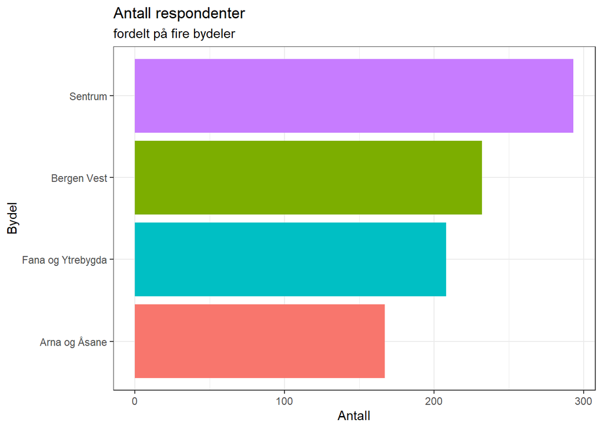

```r
# Oversikt over respondenter fordelt på fire bydeler:
d_factored %>% group_by(Bydel) %>% count(Bydel) %>% ggplot(aes(x = fct_reorder(Bydel, n), y = n, fill = Bydel)) + geom_col() + labs(title = "Antall respondenter", subtitle = "fordelt på fire bydeler", x = "Bydel", y = "Antall") + guides(fill = FALSE) + coord_flip() + theme_bw()
```

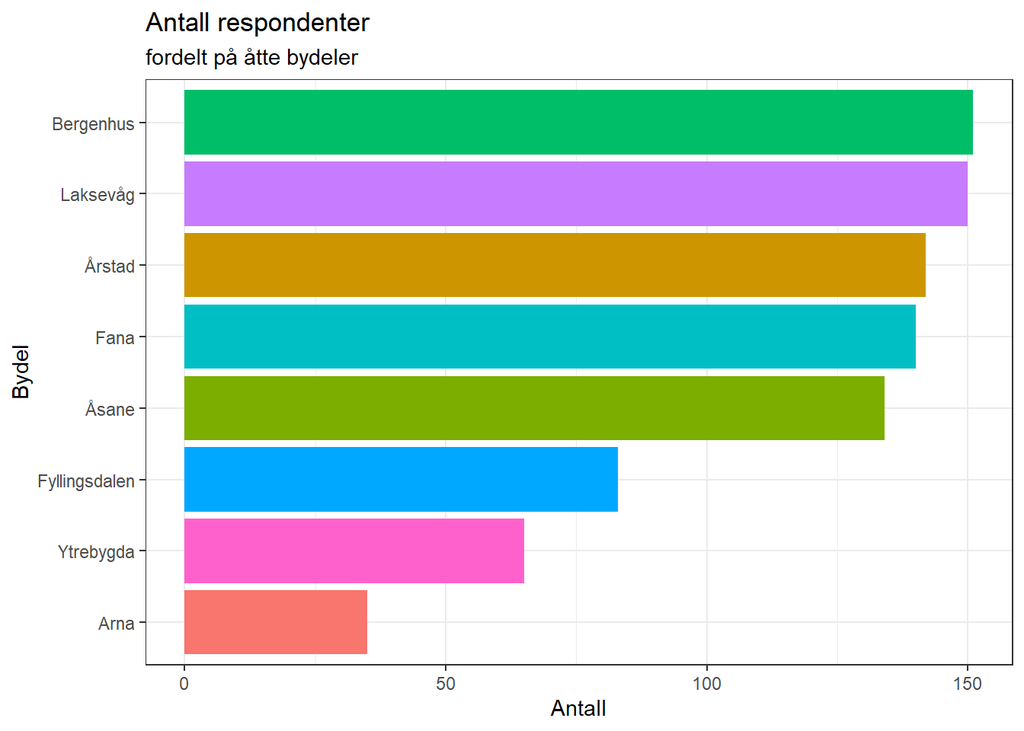

```r
# Oversikt over respondenter fordelt på åtte bydeler:
d_factored %>% group_by(bydel_8) %>% count(bydel_8) %>% ggplot(aes(x = fct_reorder(bydel_8, n), y = n, fill = bydel_8)) + geom_col() + labs(title = "Antall respondenter", subtitle = "fordelt på åtte bydeler", x = "Bydel", y = "Antall") + guides(fill = FALSE) + coord_flip() + theme_bw()
```

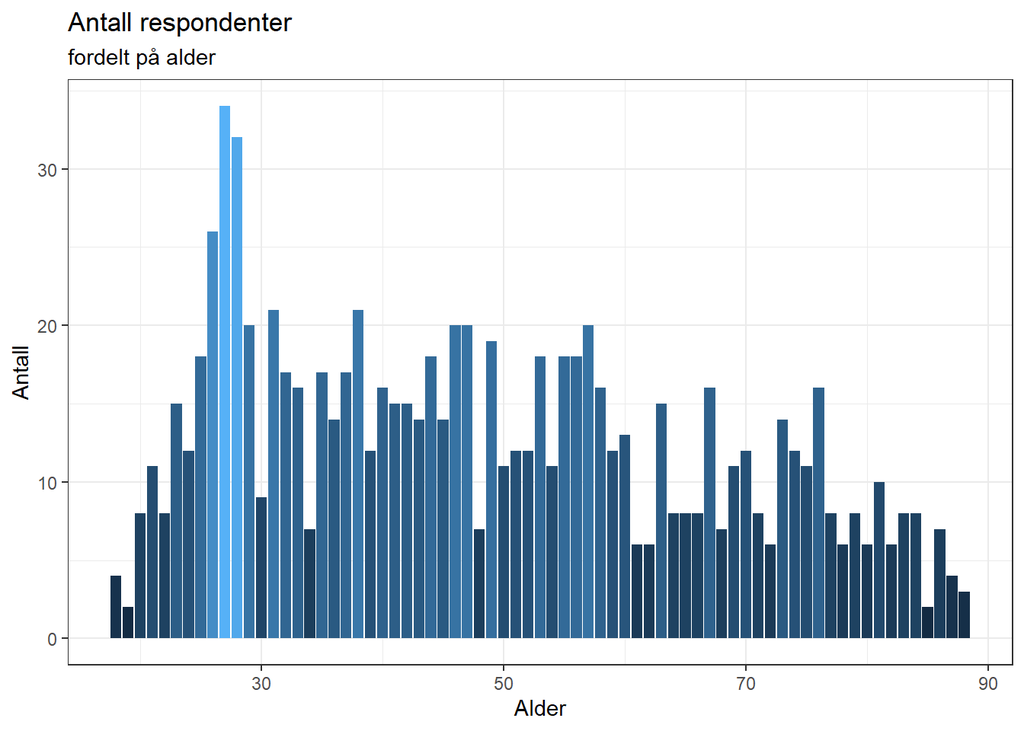

```r
# Oversikt over alder:
d_factored %>% group_by(alder) %>% count(alder) %>% ggplot(aes(x = alder, y = n, fill = n)) + geom_col() + labs(title = "Antall respondenter", subtitle = "fordelt på alder", x = "Alder", y = "Antall") + guides(fill = FALSE) + theme_bw()
```

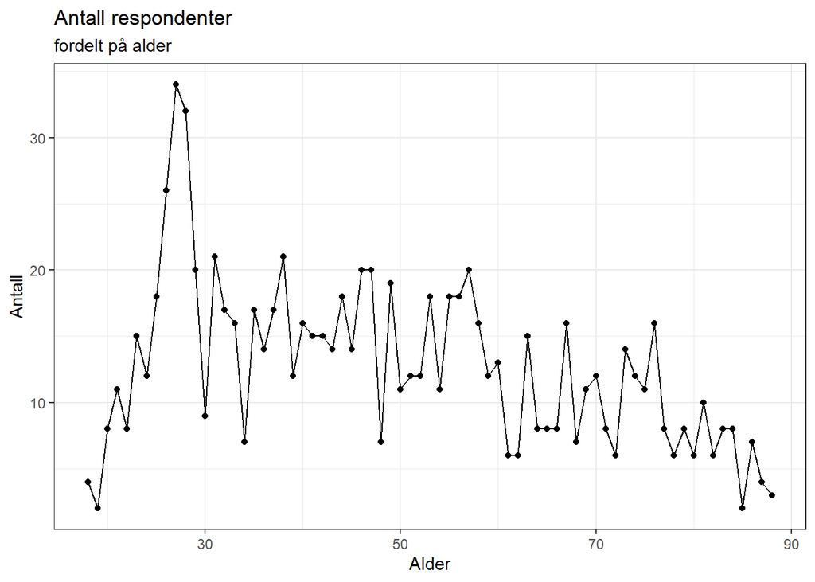

```r
d_factored %>% group_by(alder) %>% count(alder) %>% ggplot(aes(x = alder, y = n, fill = n)) + geom_point() + geom_line() + labs(title = "Antall respondenter", subtitle = "fordelt på alder", x = "Alder", y = "Antall") + guides(fill = FALSE) + theme_bw()
```

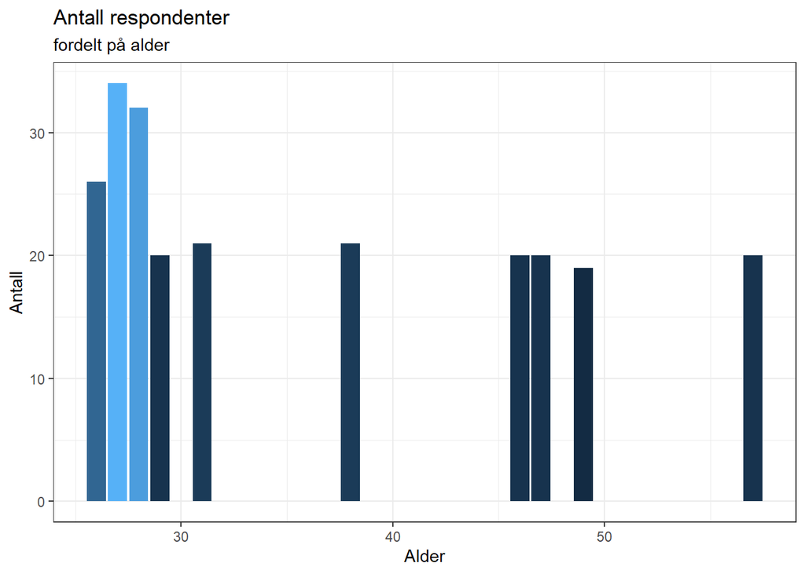

```r
d_factored %>% group_by(alder) %>% count(alder) %>% arrange(desc(n)) %>% head(10) %>% ggplot(aes(x = alder, y = n, fill = n)) + geom_col() + theme_bw() + guides(fill = FALSE) + labs(title = "Antall respondenter", subtitle = "fordelt på alder", x = "Alder", y = "Antall")
```

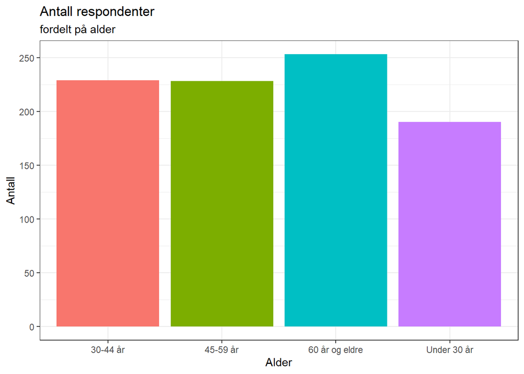

```r
# Oversikt over alder - kategori:
d_factored %>% group_by(aldrkat) %>% count(aldrkat) %>% ggplot(aes(x = aldrkat, y = n, fill = aldrkat)) + geom_col(binwidth = 1) + labs(title = "Antall respondenter", subtitle = "fordelt på alder", x = "Alder", y = "Antall") + guides(fill = FALSE) + theme_bw()
```

Vi har litt færre personer som er under 30 år sammenliknet med resten av utvalget. Tilsvarende flere blant de som er 60 år og eldre har svart på undersøkelsen. Dersom vi ikke grupperer respondentene i kategorier, så er det noe overrepresentasjon blant 27-åringer (n = 34), 28-åringer (n = 32) og 26-åringer (n = 26) - altså: Selv om yngre i litt mindre grad har svart på undersøkelsen, har vi høyest konsentrasjon rundt enkelte konkrete årskull.

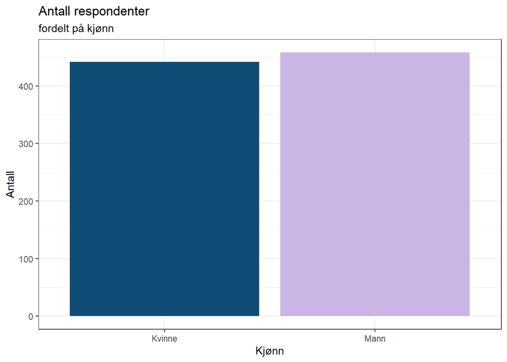

```r
# Kjønn
d_factored %>% group_by(gender) %>% count(gender) %>% ggplot(aes(x = fct_reorder(gender, n), y = n, fill = gender)) + geom_col() + scale_fill_manual(values = c("#0f4c75", "#c9b6e4")) + labs(title = "Antall respondenter", subtitle = "fordelt på kjønn", x = "Kjønn", y = "Antall") + guides(fill = FALSE) + theme_bw()
```

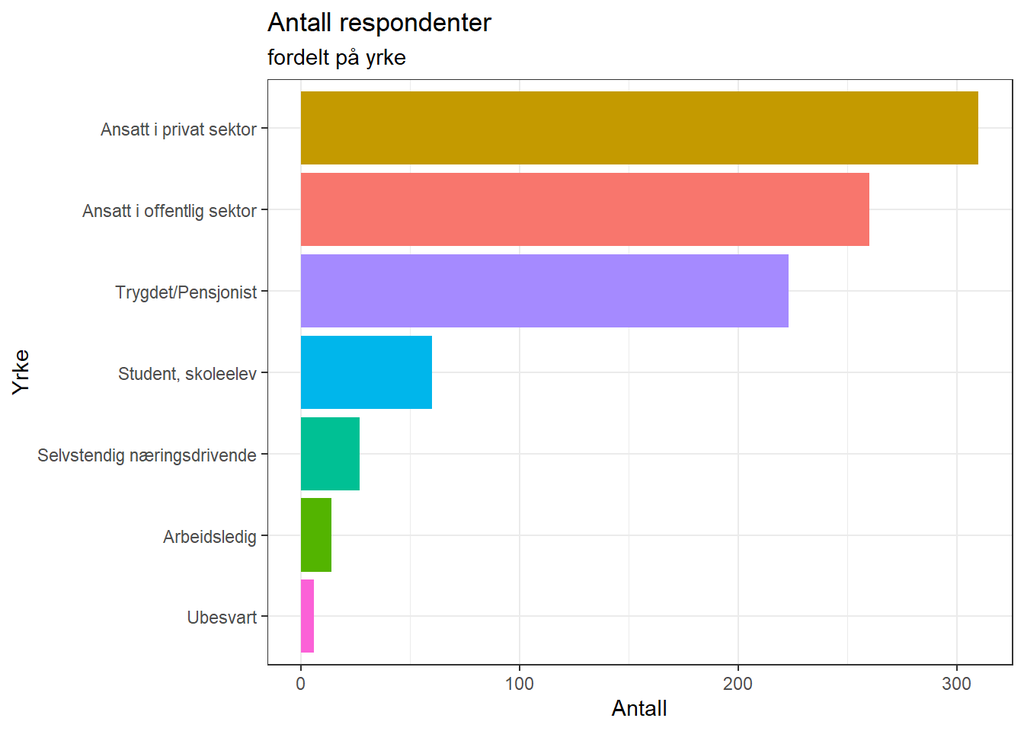

```r
# Yrke:
d_factored %>% group_by(jobb) %>% count(jobb) %>% ggplot(aes(x = (fct_reorder(jobb, n)), y = n, fill = jobb)) + geom_col() + labs(title = "Antall respondenter", subtitle = "fordelt på yrke", x = "Yrke", y = "Antall") + guides(fill = FALSE) + coord_flip() + theme_bw()
```

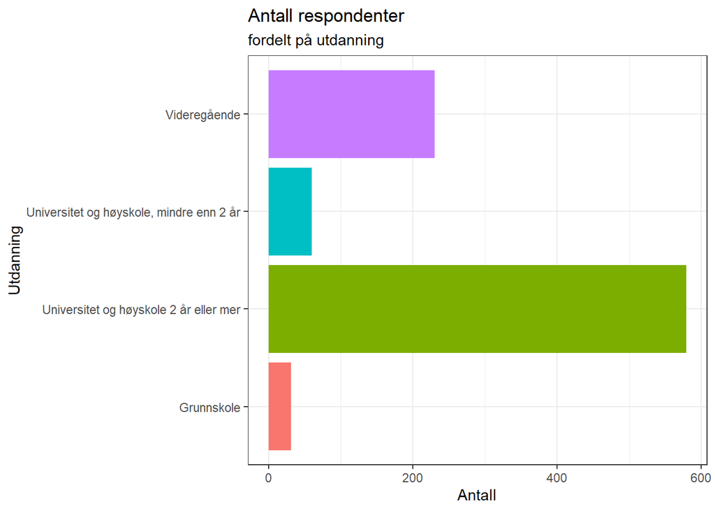

```r
# Utdanning:
d_factored %>% group_by(utdanning) %>% count(utdanning) %>% ggplot(aes(x = utdanning, y = n, fill = utdanning)) + geom_col() + labs(title = "Antall respondenter", subtitle = "fordelt på utdanning", x = "Utdanning", y = "Antall") + guides(fill = FALSE) + coord_flip() + theme_bw()
```

```r
d_factored %>% group_by(utdanning) %>% count(utdanning)
```

```
## # A tibble: 4 x 2
## # Groups:   utdanning [4]
##   utdanning                                    n
##   <chr>                                    <int>
## 1 Grunnskole                                  31
## 2 Universitet og høyskole 2 år eller mer     579
## 3 Universitet og høyskole, mindre enn 2 år    60
## 4 Videregående                               230
```

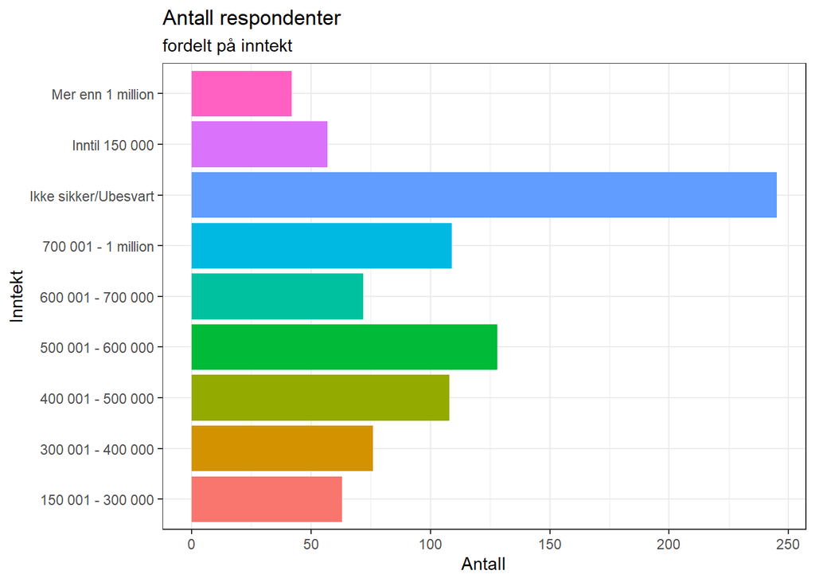

```r
# Inntekt
d_factored %>% group_by(inntekt) %>% count(inntekt) %>% ggplot(aes(x = inntekt, y = n, fill = inntekt)) + geom_col() + labs(title = "Antall respondenter", subtitle = "fordelt på inntekt", x = "Inntekt", y = "Antall") + guides(fill = FALSE) + coord_flip() + theme_bw()
```

```r
d_factored %>% group_by(inntekt) %>% count(inntekt)
```

```
## # A tibble: 9 x 2
## # Groups:   inntekt [9]
##   inntekt                  n
##   <chr>                <int>
## 1 150 001 - 300 000       63
## 2 300 001 - 400 000       76
## 3 400 001 - 500 000      108
## 4 500 001 - 600 000      128
## 5 600 001 - 700 000       72
## 6 700 001 - 1 million    109
## 7 Ikke sikker/Ubesvart   245
## 8 Inntil 150 000          57
## 9 Mer enn 1 million       42
```

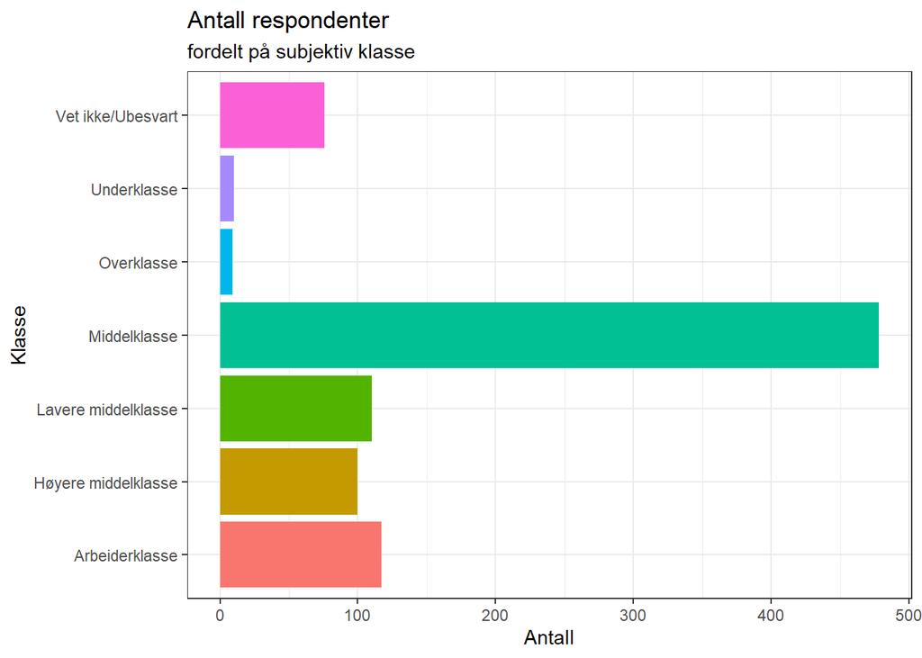

```r
# Subjektiv klasse:
d_factored %>% group_by(klasse) %>% count(klasse) %>% ggplot(aes(x = klasse, y = n, fill = klasse)) + geom_col() + labs(title = "Antall respondenter", subtitle = "fordelt på subjektiv klasse", x = "Klasse", y = "Antall") + guides(fill = FALSE) + coord_flip() + theme_bw()
```

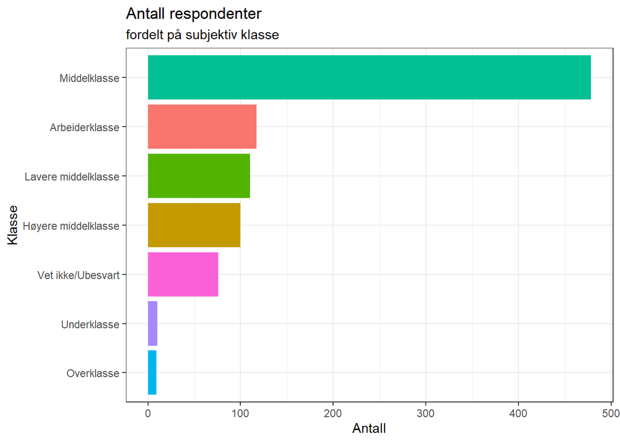

```r
d_factored %>% group_by(klasse) %>% count(klasse) %>% ggplot(aes(x = (fct_reorder(klasse, n)), y = n, fill = klasse)) + geom_col() + labs(title = "Antall respondenter", subtitle = "fordelt på subjektiv klasse", x = "Klasse", y = "Antall") + guides(fill = FALSE) + coord_flip() + theme_bw()
```

```r
d_factored %>% group_by(klasse) %>% count(klasse) %>% arrange(desc(n))
```

```
## # A tibble: 7 x 2
## # Groups:   klasse [7]
##   klasse                  n
##   <chr>               <int>
## 1 Middelklasse          478
## 2 Arbeiderklasse        117
## 3 Lavere middelklasse   110
## 4 Høyere middelklasse   100
## 5 Vet ikke/Ubesvart      76
## 6 Underklasse            10
## 7 Overklasse              9
```

Omtrent likt fordelt på kjønn - 458 menn og 442 kvinner. De fleste respondentene jobber i privat sektor (310), så kommer offentlig sektor (260). Overraskende (?) mange er trygdet eller pensjonist (223). Så følger studenter (60), selvstendig næringsdrivende (27), arbeidsledige (14) og ubesvart (6).

Selvrapportert utdanningsnivå er nærmest sjokkerende skjev; Grunnskole (31), Videregående (230), Universitet opp til 2 år (60), Universitet over 2 år (579).

Svært mange vil ikke oppgi inntekten sin og har desidert flest respondenter på dette spørsmålet (245). Ellers ser man en tendens mot normalfordeling, dog med en noe høy andel respondenter i kategorien 700 000 - 1 million.

De absolutt fleste rapporterer at de føler at de er i middelklassen. Så er det relativt jevnt mellom arbeiderklasse, lavere middelklasse og høyere middelklasse. Kun henholdsvis 10 og 9 respondenter rapporterer at de føler de er i underklasse eller overklasse. Kan henge sammen med at utvalget er skjevfordelt ihht utdanning?

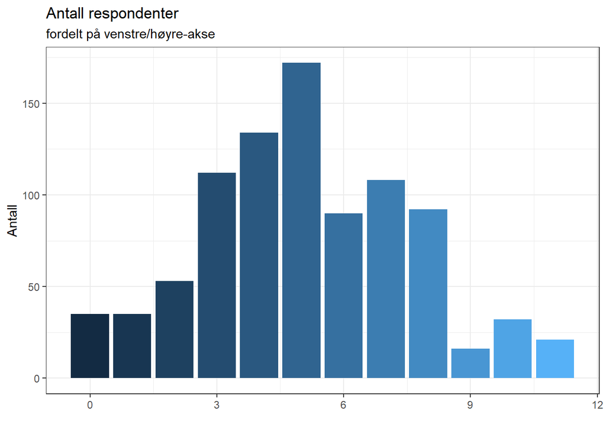

```r
# Venstre-høyre-akse:
# 21 personer har ikke svart
d_factored %>% group_by(vhakse) %>% count(vhakse) %>% filter(vhakse != "Ikke sikker/Ubesvart") %>% ggplot(aes(x = vhakse, y = n, fill = vhakse)) + geom_col() + labs(title = "Antall respondenter", subtitle = "fordelt på venstre/høyre-akse", x = "", y = "Antall") + guides(fill = FALSE) + theme_bw()
```

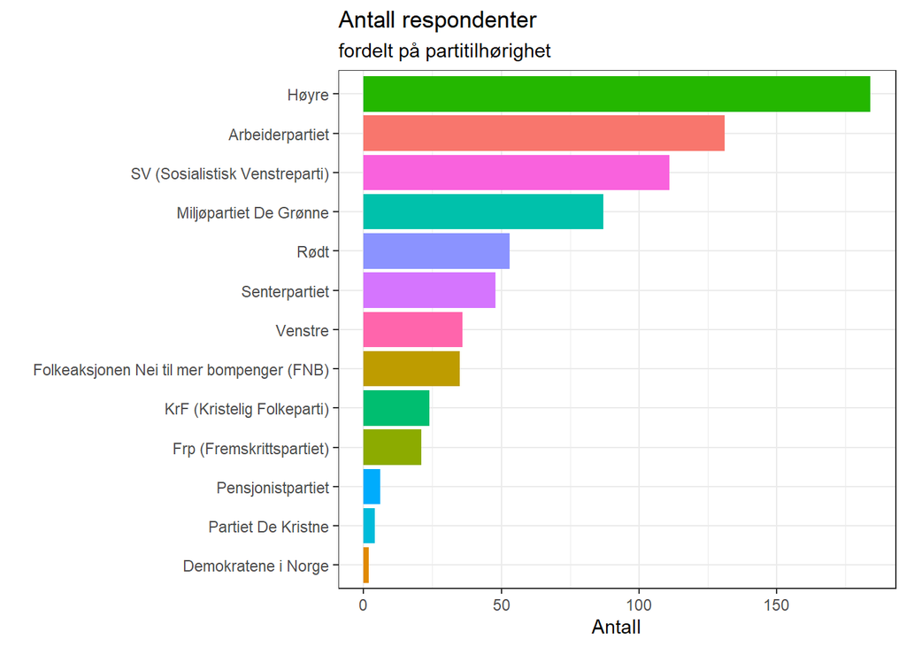

```r
# Partitilhørighet (R1DEMOVATE13):
# Har i første figur filtrert ut alle alternativer for "Annet", "Vil ikke si", osv..
d_factored %>% group_by(parti) %>% count(parti) %>% filter(parti != "Vil ikke stemme /Vil stemme blankt" & parti != "Vil ikke si" & parti != "Andre" & parti != "Ikke sikker") %>% ggplot(aes(x = fct_reorder(parti, n), y = n, fill = parti)) + geom_col() + labs(title = "Antall respondenter", subtitle = "fordelt på partitilhørighet", x = "", y = "Antall") + guides(fill = FALSE) + coord_flip() + theme_bw()
```

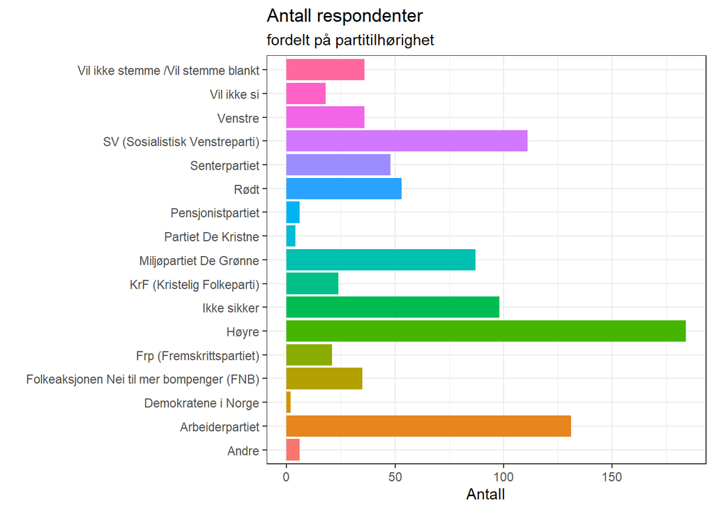

```r
d_factored %>% group_by(parti) %>% count(parti) %>% ggplot(aes(x = parti, y = n, fill = parti)) + geom_col() + labs(title = "Antall respondenter", subtitle = "fordelt på partitilhørighet", x = "", y = "Antall") + guides(fill = FALSE) + coord_flip() + theme_bw()
```

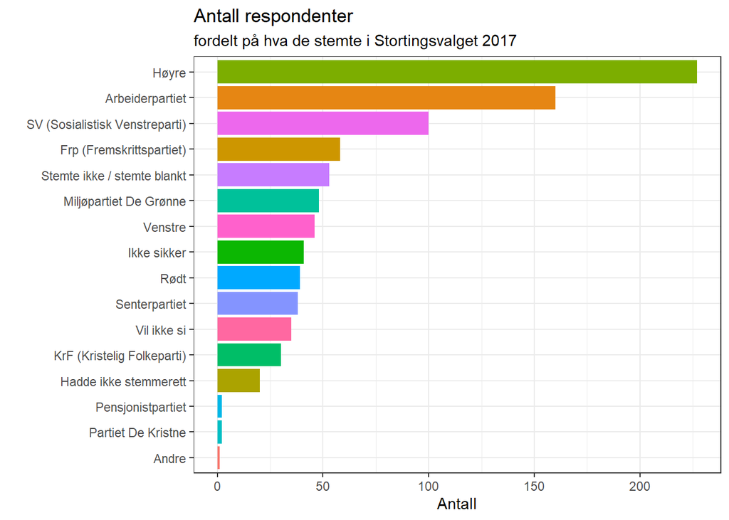

```r
# Stemt ved stortingsvalget 2017:
d_factored %>% group_by(svalg17) %>% count(svalg17) %>% filter(svalg17 != "Ikke sikker/Ubesvart") %>% ggplot(aes(x = fct_reorder(svalg17, n), y = n, fill = svalg17)) + geom_col() + labs(title = "Antall respondenter", subtitle = "fordelt på hva de stemte i Stortingsvalget 2017", x = "", y = "Antall") + guides(fill = FALSE) + coord_flip() + theme_bw()
```

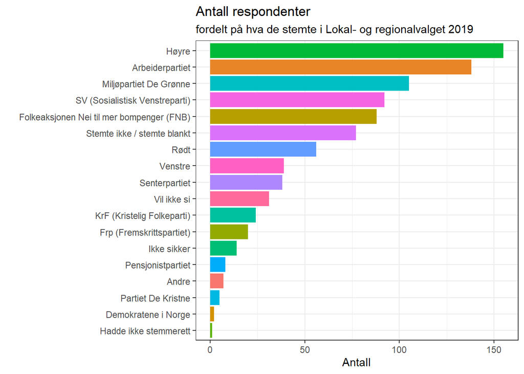

```r
# Stemt ved Lokalvalget 2019:
d_factored %>% group_by(lvalg19) %>% count(lvalg19) %>% filter(lvalg19 != "Ikke sikker/Ubesvart") %>% ggplot(aes(x = fct_reorder(lvalg19, n), y = n, fill = lvalg19)) + geom_col() + labs(title = "Antall respondenter", subtitle = "fordelt på hva de stemte i Lokal- og regionalvalget 2019", x = "", y = "Antall") + guides(fill = FALSE) + coord_flip() + theme_bw()
```

Utvalget er ideologisk ut fra venstre/høyre-aksen subjektivt normalfordelt, hvor de absolutt fleste er rundt “5” på en skala fra 1 / 10. Men det skurrer litt med partiene de utgir seg for å ha stemt på eller sympatiserer med. Her er Høyre klart i flertall. Men kanskje det at det er størst opplsutning rundt Høyre kan forklares av at det er relativt få selverklærte FrP-velgere i utvalget. Kampen om stemmene i midten eller litt til venstre for midten i Norge er det hard kamp om.

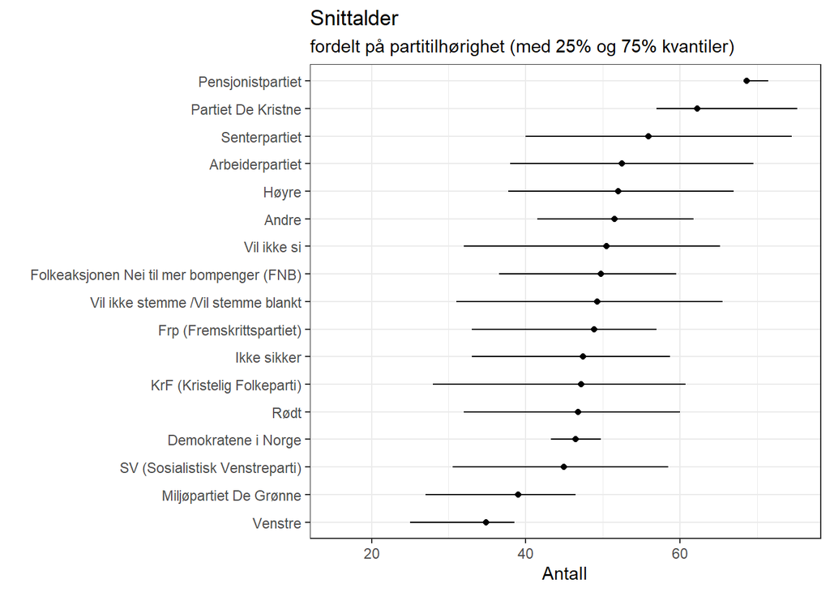

```r
# Hvordan er aldersfordelingen på partitilhørighet?
d_factored %>% group_by(parti) %>%
  summarize(snitt = mean(alder),
            q25 = quantile(alder, 0.25),
            q75 = quantile(alder, 0.75)) %>%
  arrange(desc(snitt)) %>%
  ggplot(aes(x = fct_reorder(parti, snitt), y = snitt)) +
  geom_point() +
  geom_linerange(aes(ymin = q25, ymax = q75)) +
  labs(title = "Snittalder", subtitle = "fordelt på partitilhørighet (med 25% og 75% kvantiler)", x = "", y = "Antall") +
  coord_flip() +
  theme_bw() +
  expand_limits(y = 15)
```

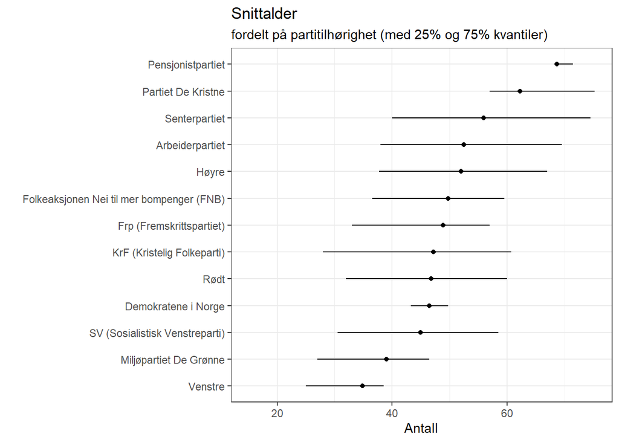

```r
# Samme som over, uten "Annet"-kategoriene:
d_factored %>% group_by(parti) %>%
  filter(parti != "Vil ikke stemme /Vil stemme blankt" & parti != "Vil ikke si" & parti != "Andre" & parti != "Ikke sikker") %>%
  summarize(snitt = mean(alder),
            q25 = quantile(alder, 0.25),
            q75 = quantile(alder, 0.75)) %>%
  arrange(desc(snitt)) %>%
  ggplot(aes(x = fct_reorder(parti, snitt), y = snitt)) +
  geom_point() +
  geom_linerange(aes(ymin = q25, ymax = q75)) +
  labs(title = "Snittalder", subtitle = "fordelt på partitilhørighet (med 25% og 75% kvantiler)", x = "", y = "Antall") +
  coord_flip() +
  theme_bw() +
  expand_limits(y = 15)
```

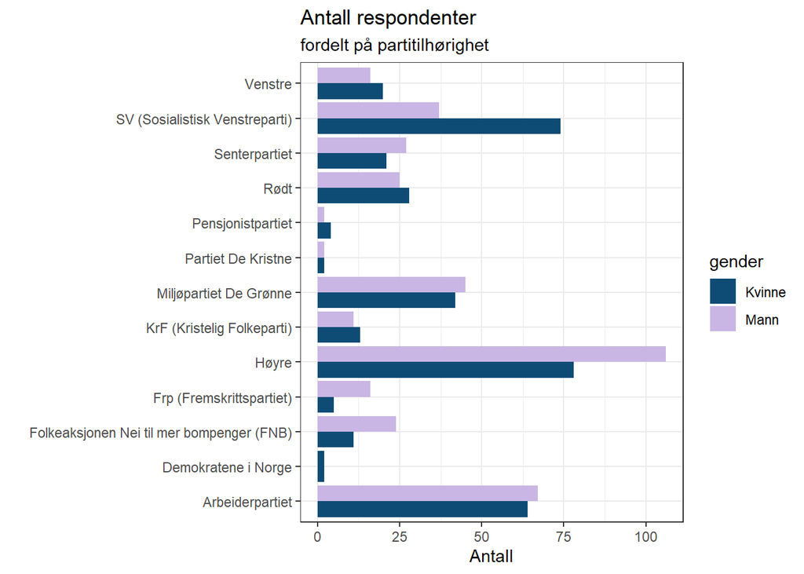

```r
# Kjønnsfordeling på partitilhørighet:
d_factored %>% group_by(parti) %>% filter(parti != "Vil ikke stemme /Vil stemme blankt" & parti != "Vil ikke si" & parti != "Andre" & parti != "Ikke sikker") %>% ggplot(aes(x = parti, fill = gender)) + geom_bar(position = "dodge") + labs(title = "Antall respondenter", subtitle = "fordelt på partitilhørighet", x = "", y = "Antall") + coord_flip() + theme_bw() + scale_fill_manual(values = c("#0f4c75", "#c9b6e4"))
```

# DATAANALYSE SURVEY OG EKSPERIMENTER:

```r
d_factored %>% glimpse()
```

```
## Rows: 900
## Columns: 101
## $ IntervjuID             <dbl> 1, 2, 3, 4, 5, 6, 7, 8, 9, 10, 11, 12, 13, 1...
## $ kommnr                 <dbl> 1201, 1201, 1201, 1201, 1201, 1201, 1201, 12...
## $ R1DEMOVATE24           <dbl> 5239, 5232, 5122, 5179, 5239, 5113, 5235, 50...
## $ Bydel                  <chr> "Fana og Ytrebygda", "Fana og Ytrebygda", "A...
## $ bydel_8                <chr> "Fana", "Fana", "Åsane", "Laksevåg", "Fana",...
## $ R1DEMOVATE21           <chr> "Kvinne", "Kvinne", "Mann", "Kvinne", "Mann"...
## $ R1DEMOVATE22           <dbl> 1973, 1987, 1943, 1943, 1952, 1994, 1954, 19...
## $ alder                  <dbl> 46, 32, 76, 76, 67, 25, 65, 35, 69, 44, 44, ...
## $ aldrkat                <chr> "45-59 år", "30-44 år", "60 år og eldre", "6...
## $ R1DEMOVATE16           <chr> "Ansatt i privat sektor", "Ansatt i privat s...
## $ R1DEMOVATE18           <chr> "Universitet og høyskole 2 år eller mer", "G...
## $ R1DEMOVATE19           <chr> "400 001 - 500 000", "Inntil 150 000", "400 ...
## $ R1DEMOVATE15           <chr> "Middelklasse", "Arbeiderklasse", "Høyere mi...
```

[output cut: 88 more lines]

```r
d_factored %>% group_by(R1DEMOVATE1) %>% count(R1DEMOVATE1)     %>% filter(R1DEMOVATE1 != "11 - Ikke sikker/Ubesvart")
```

```
## # A tibble: 12 x 2
## # Groups:   R1DEMOVATE1 [12]
##    R1DEMOVATE1     n
##          <dbl> <int>
##  1           0    36
##  2           1     7
##  3           2    18
##  4           3    25
##  5           4    23
##  6           5   146
##  7           6    68
##  8           7   110
##  9           8   154
## 10           9    41
## 11          10   256
## 12          11    16
```

```r
d_factored %>% group_by(R1DEMOVATE2) %>% count(R1DEMOVATE2)     %>% filter(R1DEMOVATE2 != "11 - Ikke sikker/Ubesvart")
```

```
## # A tibble: 12 x 2
## # Groups:   R1DEMOVATE2 [12]
##    R1DEMOVATE2     n
##          <dbl> <int>
##  1           0   223
##  2           1    41
##  3           2    64
##  4           3    68
##  5           4    44
##  6           5   181
##  7           6    48
##  8           7    54
##  9           8    72
## 10           9     9
## 11          10    72
## 12          11    24
```

```r
d_factored %>% group_by(R1DEMOVATE3) %>% count(R1DEMOVATE3)     %>% filter(R1DEMOVATE3 != "11 - Ikke sikker/Ubesvart")
```

```
## # A tibble: 12 x 2
## # Groups:   R1DEMOVATE3 [12]
##    R1DEMOVATE3     n
##          <dbl> <int>
##  1           0    76
##  2           1    44
##  3           2    65
##  4           3    80
##  5           4    65
##  6           5   201
##  7           6    66
##  8           7    78
##  9           8    88
## 10           9    25
## 11          10   100
## 12          11    12
```

```r
d_factored %>% group_by(R1DEMOVATE4) %>% count(R1DEMOVATE4)     %>% filter(R1DEMOVATE4 != "11 - Ikke sikker/Ubesvart")
```

```
## # A tibble: 12 x 2
## # Groups:   R1DEMOVATE4 [12]
##    R1DEMOVATE4     n
##          <dbl> <int>
##  1           0    23
##  2           1     7
##  3           2    18
##  4           3    25
##  5           4    39
##  6           5   128
##  7           6    55
##  8           7   112
##  9           8   135
## 10           9    45
## 11          10   306
## 12          11     7
```

```r
d_factored %>% group_by(R1DEMOVATE5) %>% count(R1DEMOVATE5)     %>% filter(R1DEMOVATE5 != "11 - Ikke sikker/Ubesvart")
```

```
## # A tibble: 12 x 2
## # Groups:   R1DEMOVATE5 [12]
##    R1DEMOVATE5     n
##          <dbl> <int>
##  1           0   116
##  2           1    42
##  3           2    42
##  4           3    47
##  5           4    47
##  6           5   142
##  7           6    34
##  8           7    69
##  9           8    86
## 10           9    29
## 11          10   242
## 12          11     4
```

# Utforske eksperimenter:

## R1Demovate6:

```r
d_factored %>% glimpse()
```

```
## Rows: 900
## Columns: 101
## $ IntervjuID             <dbl> 1, 2, 3, 4, 5, 6, 7, 8, 9, 10, 11, 12, 13, 1...
## $ kommnr                 <dbl> 1201, 1201, 1201, 1201, 1201, 1201, 1201, 12...
## $ R1DEMOVATE24           <dbl> 5239, 5232, 5122, 5179, 5239, 5113, 5235, 50...
## $ Bydel                  <chr> "Fana og Ytrebygda", "Fana og Ytrebygda", "A...
## $ bydel_8                <chr> "Fana", "Fana", "Åsane", "Laksevåg", "Fana",...
## $ R1DEMOVATE21           <chr> "Kvinne", "Kvinne", "Mann", "Kvinne", "Mann"...
## $ R1DEMOVATE22           <dbl> 1973, 1987, 1943, 1943, 1952, 1994, 1954, 19...
## $ alder                  <dbl> 46, 32, 76, 76, 67, 25, 65, 35, 69, 44, 44, ...
## $ aldrkat                <chr> "45-59 år", "30-44 år", "60 år og eldre", "6...
## $ R1DEMOVATE16           <chr> "Ansatt i privat sektor", "Ansatt i privat s...
## $ R1DEMOVATE18           <chr> "Universitet og høyskole 2 år eller mer", "G...
## $ R1DEMOVATE19           <chr> "400 001 - 500 000", "Inntil 150 000", "400 ...
## $ R1DEMOVATE15           <chr> "Middelklasse", "Arbeiderklasse", "Høyere mi...
```

[output cut: 88 more lines]

```r
d_factored %>% group_by(Alternativ)  %>% count(Alternativ)
```

```
## # A tibble: 2 x 2
## # Groups:   Alternativ [2]
##   Alternativ     n
##        <dbl> <int>
## 1          1   446
## 2          2   454
```

```r
d_factored %>% group_by(R1DEMOVATE6_Antall1)          %>% count(R1DEMOVATE6_Antall1)          %>% filter(!is.na(R1DEMOVATE6_Antall1))
```

```
## # A tibble: 3 x 2
## # Groups:   R1DEMOVATE6_Antall1 [3]
##   R1DEMOVATE6_Antall1     n
##   <fct>               <int>
## 1 12                    135
## 2 100                   166
## 3 300                   145
```

```r
d_factored %>% group_by(R1DEMOVATE6_Dag1)             %>% count(R1DEMOVATE6_Dag1)             %>% filter(!is.na(R1DEMOVATE6_Dag1))
```

```
## # A tibble: 2 x 2
## # Groups:   R1DEMOVATE6_Dag1 [2]
##   R1DEMOVATE6_Dag1     n
##   <fct>            <int>
## 1 hverdag            244
## 2 helgedag           202
```

```r
d_factored %>% group_by(R1DEMOVATE6_Rekr1)            %>% count(R1DEMOVATE6_Rekr1)            %>% filter(!is.na(R1DEMOVATE6_Rekr1))
```

```
## # A tibble: 2 x 2
## # Groups:   R1DEMOVATE6_Rekr1 [2]
##   R1DEMOVATE6_Rekr1                                                         n
##   <fct>                                                                 <int>
## 1 Registrering er åpen for alle innbyggerne i kommunen til det er fullt   243
## 2 Deltakerne trekkes tilfeldig blant alle innbyggerne i kommunen          203
```

```r
d_factored %>% group_by(R1DEMOVATE6_Komp1)            %>% count(R1DEMOVATE6_Komp1)            %>% filter(!is.na(R1DEMOVATE6_Komp1))
```

```
## # A tibble: 4 x 2
## # Groups:   R1DEMOVATE6_Komp1 [4]
##   R1DEMOVATE6_Komp1                       n
##   <fct>                               <int>
## 1 ikke kompensert                       114
## 2 kompensert med 200 kroner per time    112
## 3 kompensert med 500 kroner per time    113
## 4 kompensert med 1000 kroner per time   107
```

```r
d_factored %>% group_by(R1DEMOVATE6_Sak1)             %>% count(R1DEMOVATE6_Sak1)             %>% filter(!is.na(R1DEMOVATE6_Sak1))
```

```
## # A tibble: 3 x 2
## # Groups:   R1DEMOVATE6_Sak1 [3]
##   R1DEMOVATE6_Sak1                         n
##   <fct>                                <int>
## 1 boligbygging på Store Lungegårdsvann   139
## 2 tiggerforbud i Bergen                  139
## 3 turistskatt                            168
```

```r
d_factored %>% group_by(R1DEMOVATE6_Grunnlag1)        %>% count(R1DEMOVATE6_Grunnlag1)        %>% filter(!is.na(R1DEMOVATE6_Grunnlag1))
```

```
## # A tibble: 3 x 2
## # Groups:   R1DEMOVATE6_Grunnlag1 [3]
##   R1DEMOVATE6_Grunnlag1                                                   n
##   <fct>                                                               <int>
## 1 egne vurderinger og preferanser                                       133
## 2 troverdig informasjon fra uavhengige eksperter                        171
## 3 meningsutveksling i mindre grupper, ledet av uavhengige moderatorer   142
```

```r
d_factored %>% group_by(R1DEMOVATE6_Offentlig1)       %>% count(R1DEMOVATE6_Offentlig1)       %>% filter(!is.na(R1DEMOVATE6_Offentlig1))
```

```
## # A tibble: 2 x 2
## # Groups:   R1DEMOVATE6_Offentlig1 [2]
##   R1DEMOVATE6_Offentlig1                                                       n
##   <fct>                                                                    <int>
## 1 Hvem som deltok i borgerpanelet og hvordan de stemte vil være offentlig    224
## 2 Hvem som deltok i borgerpanelet og hvordan de stemte vil ikke være offe~   222
```

```r
d_factored %>% group_by(R1DEMOVATE6_1)                %>% count(R1DEMOVATE6_1)                %>% filter(!is.na(R1DEMOVATE6_1))
```

```
## # A tibble: 31 x 2
## # Groups:   R1DEMOVATE6_1 [31]
##    R1DEMOVATE6_1     n
##            <dbl> <int>
##  1             0   102
##  2             1     9
##  3             2     5
##  4             3     5
##  5             4     4
##  6             5     9
##  7             6     3
##  8             7     2
##  9             8     2
## 10             9     3
## # ... with 21 more rows
```

```r
d_factored %>% group_by(R1DEMOVATE6_Antall2)          %>% count(R1DEMOVATE6_Antall2)          %>% filter(!is.na(R1DEMOVATE6_Antall2))
```

```
## # A tibble: 3 x 2
## # Groups:   R1DEMOVATE6_Antall2 [3]
##   R1DEMOVATE6_Antall2     n
##   <fct>               <int>
## 1 12                    144
## 2 100                   163
## 3 300                   139
```

```r
d_factored %>% group_by(R1DEMOVATE6_Dag2)             %>% count(R1DEMOVATE6_Dag2)             %>% filter(!is.na(R1DEMOVATE6_Dag2))
```

```
## # A tibble: 2 x 2
## # Groups:   R1DEMOVATE6_Dag2 [2]
##   R1DEMOVATE6_Dag2     n
##   <fct>            <int>
## 1 hverdag            223
## 2 helgedag           223
```

```r
d_factored %>% group_by(R1DEMOVATE6_Rekr2)            %>% count(R1DEMOVATE6_Rekr2)            %>% filter(!is.na(R1DEMOVATE6_Rekr2))
```

```
## # A tibble: 2 x 2
## # Groups:   R1DEMOVATE6_Rekr2 [2]
##   R1DEMOVATE6_Rekr2                                                         n
##   <fct>                                                                 <int>
## 1 Registrering er åpen for alle innbyggerne i kommunen til det er fullt   222
## 2 Deltakerne trekkes tilfeldig blant alle innbyggerne i kommunen          224
```

```r
d_factored %>% group_by(R1DEMOVATE6_Komp2)            %>% count(R1DEMOVATE6_Komp2)            %>% filter(!is.na(R1DEMOVATE6_Komp2))
```

```
## # A tibble: 4 x 2
## # Groups:   R1DEMOVATE6_Komp2 [4]
##   R1DEMOVATE6_Komp2                       n
##   <fct>                               <int>
## 1 ikke kompensert                       115
## 2 kompensert med 200 kroner per time    123
## 3 kompensert med 500 kroner per time    110
## 4 kompensert med 1000 kroner per time    98
```

```r
d_factored %>% group_by(R1DEMOVATE6_Sak2)             %>% count(R1DEMOVATE6_Sak2)             %>% filter(!is.na(R1DEMOVATE6_Sak2))
```

```
## # A tibble: 3 x 2
## # Groups:   R1DEMOVATE6_Sak2 [3]
##   R1DEMOVATE6_Sak2                         n
##   <fct>                                <int>
## 1 boligbygging på Store Lungegårdsvann   156
## 2 tiggerforbud i Bergen                  159
## 3 turistskatt                            131
```

```r
d_factored %>% group_by(R1DEMOVATE6_Grunnlag2)        %>% count(R1DEMOVATE6_Grunnlag2)        %>% filter(!is.na(R1DEMOVATE6_Grunnlag2))
```

```
## # A tibble: 3 x 2
## # Groups:   R1DEMOVATE6_Grunnlag2 [3]
##   R1DEMOVATE6_Grunnlag2                                                   n
##   <fct>                                                               <int>
## 1 egne vurderinger og preferanser                                       142
## 2 troverdig informasjon fra uavhengige eksperter                        150
## 3 meningsutveksling i mindre grupper, ledet av uavhengige moderatorer   154
```

```r
d_factored %>% group_by(R1DEMOVATE6_Offentlig2)       %>% count(R1DEMOVATE6_Offentlig2)       %>% filter(!is.na(R1DEMOVATE6_Offentlig2))
```

```
## # A tibble: 2 x 2
## # Groups:   R1DEMOVATE6_Offentlig2 [2]
##   R1DEMOVATE6_Offentlig2                                                       n
##   <fct>                                                                    <int>
## 1 Hvem som deltok i borgerpanelet og hvordan de stemte vil være offentlig    217
## 2 Hvem som deltok i borgerpanelet og hvordan de stemte vil ikke være offe~   229
```

```r
d_factored %>% group_by(R1DEMOVATE6_2)                %>% count(R1DEMOVATE6_2)                %>% filter(!is.na(R1DEMOVATE6_2))
```

```
## # A tibble: 32 x 2
## # Groups:   R1DEMOVATE6_2 [32]
##    R1DEMOVATE6_2     n
##            <dbl> <int>
##  1             0   110
##  2             1     7
##  3             2     6
##  4             3     3
##  5             4     5
##  6             5     9
##  7             6     2
##  8             7     3
##  9             8     2
## 10             9     1
## # ... with 22 more rows
```

```r
d_factored %>% group_by(R1DEMOVATE6_Antall3)              %>% count(R1DEMOVATE6_Antall3)          %>% filter(!is.na(R1DEMOVATE6_Antall3))
```

```
## # A tibble: 3 x 2
## # Groups:   R1DEMOVATE6_Antall3 [3]
##   R1DEMOVATE6_Antall3     n
##   <fct>               <int>
## 1 12                    152
## 2 100                   150
## 3 300                   144
```

```r
d_factored %>% group_by(R1DEMOVATE6_Dag3)                 %>% count(R1DEMOVATE6_Dag3)             %>% filter(!is.na(R1DEMOVATE6_Dag3))
```

```
## # A tibble: 2 x 2
## # Groups:   R1DEMOVATE6_Dag3 [2]
##   R1DEMOVATE6_Dag3     n
##   <fct>            <int>
## 1 hverdag            219
## 2 helgedag           227
```

```r
d_factored %>% group_by(R1DEMOVATE6_Rekr3)                %>% count(R1DEMOVATE6_Rekr3)            %>% filter(!is.na(R1DEMOVATE6_Rekr3))
```

```
## # A tibble: 2 x 2
## # Groups:   R1DEMOVATE6_Rekr3 [2]
##   R1DEMOVATE6_Rekr3                                                         n
##   <fct>                                                                 <int>
## 1 Registrering er åpen for alle innbyggerne i kommunen til det er fullt   213
## 2 Deltakerne trekkes tilfeldig blant alle innbyggerne i kommunen          233
```

```r
d_factored %>% group_by(R1DEMOVATE6_Komp3)                %>% count(R1DEMOVATE6_Komp3)            %>% filter(!is.na(R1DEMOVATE6_Komp3))
```

```
## # A tibble: 4 x 2
## # Groups:   R1DEMOVATE6_Komp3 [4]
##   R1DEMOVATE6_Komp3                       n
##   <fct>                               <int>
## 1 ikke kompensert                       105
## 2 kompensert med 200 kroner per time    120
## 3 kompensert med 500 kroner per time    118
## 4 kompensert med 1000 kroner per time   103
```

```r
d_factored %>% group_by(R1DEMOVATE6_Sak3)                 %>% count(R1DEMOVATE6_Sak3)             %>% filter(!is.na(R1DEMOVATE6_Sak3))
```

```
## # A tibble: 3 x 2
## # Groups:   R1DEMOVATE6_Sak3 [3]
##   R1DEMOVATE6_Sak3                         n
##   <fct>                                <int>
## 1 boligbygging på Store Lungegårdsvann   142
## 2 tiggerforbud i Bergen                  171
## 3 turistskatt                            133
```

```r
d_factored %>% group_by(R1DEMOVATE6_Grunnlag3)            %>% count(R1DEMOVATE6_Grunnlag3)        %>% filter(!is.na(R1DEMOVATE6_Grunnlag3))
```

```
## # A tibble: 3 x 2
## # Groups:   R1DEMOVATE6_Grunnlag3 [3]
##   R1DEMOVATE6_Grunnlag3                                                   n
##   <fct>                                                               <int>
## 1 egne vurderinger og preferanser                                       156
## 2 troverdig informasjon fra uavhengige eksperter                        138
## 3 meningsutveksling i mindre grupper, ledet av uavhengige moderatorer   152
```

```r
d_factored %>% group_by(R1DEMOVATE6_Offentlig3)           %>% count(R1DEMOVATE6_Offentlig3)       %>% filter(!is.na(R1DEMOVATE6_Offentlig3))
```

```
## # A tibble: 2 x 2
## # Groups:   R1DEMOVATE6_Offentlig3 [2]
##   R1DEMOVATE6_Offentlig3                                                       n
##   <fct>                                                                    <int>
## 1 Hvem som deltok i borgerpanelet og hvordan de stemte vil være offentlig    222
## 2 Hvem som deltok i borgerpanelet og hvordan de stemte vil ikke være offe~   224
```

```r
d_factored %>% group_by(R1DEMOVATE6_3)                    %>% count(R1DEMOVATE6_3)                %>% filter(!is.na(R1DEMOVATE6_3))
```

```
## # A tibble: 32 x 2
## # Groups:   R1DEMOVATE6_3 [32]
##    R1DEMOVATE6_3     n
##            <dbl> <int>
##  1             0   121
##  2             1     5
##  3             2     6
##  4             3     5
##  5             4     4
##  6             5    12
##  7             6     2
##  8             7     3
##  9             8     2
## 10             9     2
## # ... with 22 more rows
```

## R1Demovate7:

```r
d_factored %>% glimpse()
```

```
## Rows: 900
## Columns: 101
## $ IntervjuID             <dbl> 1, 2, 3, 4, 5, 6, 7, 8, 9, 10, 11, 12, 13, 1...
## $ kommnr                 <dbl> 1201, 1201, 1201, 1201, 1201, 1201, 1201, 12...
## $ R1DEMOVATE24           <dbl> 5239, 5232, 5122, 5179, 5239, 5113, 5235, 50...
## $ Bydel                  <chr> "Fana og Ytrebygda", "Fana og Ytrebygda", "A...
## $ bydel_8                <chr> "Fana", "Fana", "Åsane", "Laksevåg", "Fana",...
## $ R1DEMOVATE21           <chr> "Kvinne", "Kvinne", "Mann", "Kvinne", "Mann"...
## $ R1DEMOVATE22           <dbl> 1973, 1987, 1943, 1943, 1952, 1994, 1954, 19...
## $ alder                  <dbl> 46, 32, 76, 76, 67, 25, 65, 35, 69, 44, 44, ...
## $ aldrkat                <chr> "45-59 år", "30-44 år", "60 år og eldre", "6...
## $ R1DEMOVATE16           <chr> "Ansatt i privat sektor", "Ansatt i privat s...
## $ R1DEMOVATE18           <chr> "Universitet og høyskole 2 år eller mer", "G...
## $ R1DEMOVATE19           <chr> "400 001 - 500 000", "Inntil 150 000", "400 ...
## $ R1DEMOVATE15           <chr> "Middelklasse", "Arbeiderklasse", "Høyere mi...
```

[output cut: 88 more lines]

```r
d_factored %>% group_by(Alternativ)  %>% count(Alternativ)
```

```
## # A tibble: 2 x 2
## # Groups:   Alternativ [2]
##   Alternativ     n
##        <dbl> <int>
## 1          1   446
## 2          2   454
```

```r
d_factored %>% group_by(R1DEMOVATE7_Antall1)      %>%   count(R1DEMOVATE7_Antall1)        %>%   filter(!is.na(R1DEMOVATE7_Antall1))
```

```
## # A tibble: 3 x 2
## # Groups:   R1DEMOVATE7_Antall1 [3]
##   R1DEMOVATE7_Antall1     n
##   <fct>               <int>
## 1 12                    151
## 2 100                   158
## 3 300                   145
```

```r
d_factored %>% group_by(R1DEMOVATE7_Dag1)         %>%   count(R1DEMOVATE7_Dag1)           %>%   filter(!is.na(R1DEMOVATE7_Dag1))
```

```
## # A tibble: 2 x 2
## # Groups:   R1DEMOVATE7_Dag1 [2]
##   R1DEMOVATE7_Dag1     n
##   <fct>            <int>
## 1 hverdag            223
## 2 helgedag           231
```

```r
d_factored %>% group_by(R1DEMOVATE7_Rekr1)        %>%   count(R1DEMOVATE7_Rekr1)          %>%   filter(!is.na(R1DEMOVATE7_Rekr1))
```

```
## # A tibble: 2 x 2
## # Groups:   R1DEMOVATE7_Rekr1 [2]
##   R1DEMOVATE7_Rekr1                                                         n
##   <fct>                                                                 <int>
## 1 Registrering er åpen for alle innbyggerne i kommunen til det er fullt   204
## 2 Deltakerne trekkes tilfeldig blant alle innbyggerne i kommunen          250
```

```r
d_factored %>% group_by(R1DEMOVATE7_Komp1)        %>%   count(R1DEMOVATE7_Komp1)          %>%   filter(!is.na(R1DEMOVATE7_Komp1))
```

```
## # A tibble: 4 x 2
## # Groups:   R1DEMOVATE7_Komp1 [4]
##   R1DEMOVATE7_Komp1                       n
##   <fct>                               <int>
## 1 ikke kompensert                       109
## 2 kompensert med 200 kroner per time    107
## 3 kompensert med 500 kroner per time    129
## 4 kompensert med 1000 kroner per time   109
```

```r
d_factored %>% group_by(R1DEMOVATE7_Sak1)         %>%   count(R1DEMOVATE7_Sak1)           %>%   filter(!is.na(R1DEMOVATE7_Sak1))
```

```
## # A tibble: 3 x 2
## # Groups:   R1DEMOVATE7_Sak1 [3]
##   R1DEMOVATE7_Sak1                         n
##   <fct>                                <int>
## 1 boligbygging på Store Lungegårdsvann   143
## 2 tiggerforbud i Bergen                  149
## 3 turistskatt                            162
```

```r
d_factored %>% group_by(R1DEMOVATE7_Grunnlag1)    %>%   count(R1DEMOVATE7_Grunnlag1)      %>%   filter(!is.na(R1DEMOVATE7_Grunnlag1))
```

```
## # A tibble: 3 x 2
## # Groups:   R1DEMOVATE7_Grunnlag1 [3]
##   R1DEMOVATE7_Grunnlag1                                                   n
##   <fct>                                                               <int>
## 1 egne vurderinger og preferanser                                       153
## 2 troverdig informasjon fra uavhengige eksperter                        149
## 3 meningsutveksling i mindre grupper, ledet av uavhengige moderatorer   152
```

```r
d_factored %>% group_by(R1DEMOVATE7_Offentlig1)   %>%   count(R1DEMOVATE7_Offentlig1)     %>%   filter(!is.na(R1DEMOVATE7_Offentlig1))
```

```
## # A tibble: 2 x 2
## # Groups:   R1DEMOVATE7_Offentlig1 [2]
##   R1DEMOVATE7_Offentlig1                                                       n
##   <fct>                                                                    <int>
## 1 Hvem som deltok i borgerpanelet og hvordan de stemte vil være offentlig    233
## 2 Hvem som deltok i borgerpanelet og hvordan de stemte vil ikke være offe~   221
```

```r
d_factored %>% group_by(R1DEMOVATE7_1)            %>%   count(R1DEMOVATE7_1)              %>%   filter(!is.na(R1DEMOVATE7_1))
```

```
## # A tibble: 12 x 2
## # Groups:   R1DEMOVATE7_1 [12]
##    R1DEMOVATE7_1     n
##            <dbl> <int>
##  1             1    66
##  2             2    17
##  3             3    22
##  4             4    32
##  5             5    33
##  6             6    84
##  7             7    45
##  8             8    57
##  9             9    44
## 10            10    10
## 11            11    32
## 12            12    12
```

```r
d_factored %>% group_by(R1DEMOVATE7_Antall2)      %>%   count(R1DEMOVATE7_Antall2)        %>%   filter(!is.na(R1DEMOVATE7_Antall2))
```

```
## # A tibble: 3 x 2
## # Groups:   R1DEMOVATE7_Antall2 [3]
##   R1DEMOVATE7_Antall2     n
##   <fct>               <int>
## 1 12                    151
## 2 100                   154
## 3 300                   149
```

```r
d_factored %>% group_by(R1DEMOVATE7_Dag2)         %>%   count(R1DEMOVATE7_Dag2)           %>%   filter(!is.na(R1DEMOVATE7_Dag2))
```

```
## # A tibble: 2 x 2
## # Groups:   R1DEMOVATE7_Dag2 [2]
##   R1DEMOVATE7_Dag2     n
##   <fct>            <int>
## 1 hverdag            239
## 2 helgedag           215
```

```r
d_factored %>% group_by(R1DEMOVATE7_Rekr2)        %>%   count(R1DEMOVATE7_Rekr2)          %>%   filter(!is.na(R1DEMOVATE7_Rekr2))
```

```
## # A tibble: 2 x 2
## # Groups:   R1DEMOVATE7_Rekr2 [2]
##   R1DEMOVATE7_Rekr2                                                         n
##   <fct>                                                                 <int>
## 1 Registrering er åpen for alle innbyggerne i kommunen til det er fullt   232
## 2 Deltakerne trekkes tilfeldig blant alle innbyggerne i kommunen          222
```

```r
d_factored %>% group_by(R1DEMOVATE7_Komp2)        %>%   count(R1DEMOVATE7_Komp2)          %>%   filter(!is.na(R1DEMOVATE7_Komp2))
```

```
## # A tibble: 4 x 2
## # Groups:   R1DEMOVATE7_Komp2 [4]
##   R1DEMOVATE7_Komp2                       n
##   <fct>                               <int>
## 1 ikke kompensert                       110
## 2 kompensert med 200 kroner per time    121
## 3 kompensert med 500 kroner per time    109
## 4 kompensert med 1000 kroner per time   114
```

```r
d_factored %>% group_by(R1DEMOVATE7_Sak2)         %>%   count(R1DEMOVATE7_Sak2)           %>%   filter(!is.na(R1DEMOVATE7_Sak2))
```

```
## # A tibble: 3 x 2
## # Groups:   R1DEMOVATE7_Sak2 [3]
##   R1DEMOVATE7_Sak2                         n
##   <fct>                                <int>
## 1 boligbygging på Store Lungegårdsvann   146
## 2 tiggerforbud i Bergen                  145
## 3 turistskatt                            163
```

```r
d_factored %>% group_by(R1DEMOVATE7_Grunnlag2)    %>%   count(R1DEMOVATE7_Grunnlag2)      %>%   filter(!is.na(R1DEMOVATE7_Grunnlag2))
```

```
## # A tibble: 3 x 2
## # Groups:   R1DEMOVATE7_Grunnlag2 [3]
##   R1DEMOVATE7_Grunnlag2                                                   n
##   <fct>                                                               <int>
## 1 egne vurderinger og preferanser                                       157
## 2 troverdig informasjon fra uavhengige eksperter                        160
## 3 meningsutveksling i mindre grupper, ledet av uavhengige moderatorer   137
```

```r
d_factored %>% group_by(R1DEMOVATE7_Offentlig2)   %>%   count(R1DEMOVATE7_Offentlig2)     %>%   filter(!is.na(R1DEMOVATE7_Offentlig2))
```

```
## # A tibble: 2 x 2
## # Groups:   R1DEMOVATE7_Offentlig2 [2]
##   R1DEMOVATE7_Offentlig2                                                       n
##   <fct>                                                                    <int>
## 1 Hvem som deltok i borgerpanelet og hvordan de stemte vil være offentlig    224
## 2 Hvem som deltok i borgerpanelet og hvordan de stemte vil ikke være offe~   230
```

```r
d_factored %>% group_by(R1DEMOVATE7_2)            %>%   count(R1DEMOVATE7_2)              %>%   filter(!is.na(R1DEMOVATE7_2))
```

```
## # A tibble: 12 x 2
## # Groups:   R1DEMOVATE7_2 [12]
##    R1DEMOVATE7_2     n
##            <dbl> <int>
##  1             1    76
##  2             2    25
##  3             3    37
##  4             4    30
##  5             5    36
##  6             6    76
##  7             7    49
##  8             8    38
##  9             9    35
## 10            10     6
## 11            11    27
## 12            12    19
```

```r
d_factored %>% group_by(R1DEMOVATE7_Antall3)      %>%   count(R1DEMOVATE7_Antall3)        %>%   filter(!is.na(R1DEMOVATE7_Antall3))
```

```
## # A tibble: 3 x 2
## # Groups:   R1DEMOVATE7_Antall3 [3]
##   R1DEMOVATE7_Antall3     n
##   <fct>               <int>
## 1 12                    146
## 2 100                   161
## 3 300                   147
```

```r
d_factored %>% group_by(R1DEMOVATE7_Dag3)         %>%   count(R1DEMOVATE7_Dag3)           %>%   filter(!is.na(R1DEMOVATE7_Dag3))
```

```
## # A tibble: 2 x 2
## # Groups:   R1DEMOVATE7_Dag3 [2]
##   R1DEMOVATE7_Dag3     n
##   <fct>            <int>
## 1 hverdag            214
## 2 helgedag           240
```

```r
d_factored %>% group_by(R1DEMOVATE7_Rekr3)        %>%   count(R1DEMOVATE7_Rekr3)          %>%   filter(!is.na(R1DEMOVATE7_Rekr3))
```

```
## # A tibble: 2 x 2
## # Groups:   R1DEMOVATE7_Rekr3 [2]
##   R1DEMOVATE7_Rekr3                                                         n
##   <fct>                                                                 <int>
## 1 Registrering er åpen for alle innbyggerne i kommunen til det er fullt   211
## 2 Deltakerne trekkes tilfeldig blant alle innbyggerne i kommunen          243
```

```r
d_factored %>% group_by(R1DEMOVATE7_Komp3)        %>%   count(R1DEMOVATE7_Komp3)          %>%   filter(!is.na(R1DEMOVATE7_Komp3))
```

```
## # A tibble: 4 x 2
## # Groups:   R1DEMOVATE7_Komp3 [4]
##   R1DEMOVATE7_Komp3                       n
##   <fct>                               <int>
## 1 ikke kompensert                       116
## 2 kompensert med 200 kroner per time    126
## 3 kompensert med 500 kroner per time     95
## 4 kompensert med 1000 kroner per time   117
```

```r
d_factored %>% group_by(R1DEMOVATE7_Sak3)         %>%   count(R1DEMOVATE7_Sak3)           %>%   filter(!is.na(R1DEMOVATE7_Sak3))
```

```
## # A tibble: 3 x 2
## # Groups:   R1DEMOVATE7_Sak3 [3]
##   R1DEMOVATE7_Sak3                         n
##   <fct>                                <int>
## 1 boligbygging på Store Lungegårdsvann   136
## 2 tiggerforbud i Bergen                  137
## 3 turistskatt                            181
```

```r
d_factored %>% group_by(R1DEMOVATE7_Grunnlag3)    %>%   count(R1DEMOVATE7_Grunnlag3)      %>%   filter(!is.na(R1DEMOVATE7_Grunnlag3))
```

```
## # A tibble: 3 x 2
## # Groups:   R1DEMOVATE7_Grunnlag3 [3]
##   R1DEMOVATE7_Grunnlag3                                                   n
##   <fct>                                                               <int>
## 1 egne vurderinger og preferanser                                       148
## 2 troverdig informasjon fra uavhengige eksperter                        140
## 3 meningsutveksling i mindre grupper, ledet av uavhengige moderatorer   166
```

```r
d_factored %>% group_by(R1DEMOVATE7_Offentlig3)   %>%   count(R1DEMOVATE7_Offentlig3)     %>%   filter(!is.na(R1DEMOVATE7_Offentlig3))
```

```
## # A tibble: 2 x 2
## # Groups:   R1DEMOVATE7_Offentlig3 [2]
##   R1DEMOVATE7_Offentlig3                                                       n
##   <fct>                                                                    <int>
## 1 Hvem som deltok i borgerpanelet og hvordan de stemte vil være offentlig    239
## 2 Hvem som deltok i borgerpanelet og hvordan de stemte vil ikke være offe~   215
```

```r
d_factored %>% group_by(R1DEMOVATE7_3)            %>%   count(R1DEMOVATE7_3)              %>%   filter(!is.na(R1DEMOVATE7_3))
```

```
## # A tibble: 12 x 2
## # Groups:   R1DEMOVATE7_3 [12]
##    R1DEMOVATE7_3     n
##            <dbl> <int>
##  1             1    81
##  2             2    28
##  3             3    45
##  4             4    35
##  5             5    36
##  6             6    67
##  7             7    35
##  8             8    40
##  9             9    34
## 10            10    10
## 11            11    26
## 12            12    17
```

# R1Demovate8 - R1Demovate11

```r
d_factored %>%  group_by(R1DEMOVATE8)     %>% count(R1DEMOVATE8)      %>% filter(R1DEMOVATE8   != 11) # 11 = 6
```

```
## # A tibble: 11 x 2
## # Groups:   R1DEMOVATE8 [11]
##    R1DEMOVATE8     n
##          <dbl> <int>
##  1           0    40
##  2           1    13
##  3           2    49
##  4           3    72
##  5           4   103
##  6           5   184
##  7           6   136
##  8           7   162
##  9           8   101
## 10           9    19
## 11          10    15
```

```r
#d_factored %>%  group_by(R1DEMOVATE89)    %>% count(R1DEMOVATE89)     %>% filter(R1DEMOVATE89  != 11) # 11 =
d_factored %>%  group_by(R1DEMOVATE9)     %>% count(R1DEMOVATE9)      %>% filter(R1DEMOVATE9   != 11) # 11 = 9
```

```
## # A tibble: 11 x 2
## # Groups:   R1DEMOVATE9 [11]
##    R1DEMOVATE9     n
##          <dbl> <int>
##  1           0    14
##  2           1     6
##  3           2    17
##  4           3    35
##  5           4    55
##  6           5   113
##  7           6   130
##  8           7   198
##  9           8   217
## 10           9    61
## 11          10    45
```

```r
d_factored %>%  group_by(R1DEMOVATE10)    %>% count(R1DEMOVATE10)     %>% filter(R1DEMOVATE10  != 11) # 11 = 26
```

```
## # A tibble: 11 x 2
## # Groups:   R1DEMOVATE10 [11]
##    R1DEMOVATE10     n
##           <dbl> <int>
##  1            0    71
##  2            1    40
##  3            2    77
##  4            3   107
##  5            4   115
##  6            5   200
##  7            6    97
##  8            7    88
##  9            8    51
## 10            9    10
## 11           10    18
```

```r
d_factored %>%  group_by(R1DEMOVATE11)    %>% count(R1DEMOVATE11)     %>% filter(R1DEMOVATE11  != 11) # 11 = 8
```

```
## # A tibble: 11 x 2
## # Groups:   R1DEMOVATE11 [11]
##    R1DEMOVATE11     n
##           <dbl> <int>
##  1            0    89
##  2            1    38
##  3            2   124
##  4            3    91
##  5            4    98
##  6            5   154
##  7            6    69
##  8            7   100
##  9            8    77
## 10            9    22
## 11           10    30
```

```r
d_factored %>% glimpse()
```

```
## Rows: 900
## Columns: 101
## $ IntervjuID             <dbl> 1, 2, 3, 4, 5, 6, 7, 8, 9, 10, 11, 12, 13, 1...
## $ kommnr                 <dbl> 1201, 1201, 1201, 1201, 1201, 1201, 1201, 12...
## $ R1DEMOVATE24           <dbl> 5239, 5232, 5122, 5179, 5239, 5113, 5235, 50...
## $ Bydel                  <chr> "Fana og Ytrebygda", "Fana og Ytrebygda", "A...
## $ bydel_8                <chr> "Fana", "Fana", "Åsane", "Laksevåg", "Fana",...
## $ R1DEMOVATE21           <chr> "Kvinne", "Kvinne", "Mann", "Kvinne", "Mann"...
## $ R1DEMOVATE22           <dbl> 1973, 1987, 1943, 1943, 1952, 1994, 1954, 19...
## $ alder                  <dbl> 46, 32, 76, 76, 67, 25, 65, 35, 69, 44, 44, ...
## $ aldrkat                <chr> "45-59 år", "30-44 år", "60 år og eldre", "6...
## $ R1DEMOVATE16           <chr> "Ansatt i privat sektor", "Ansatt i privat s...
## $ R1DEMOVATE18           <chr> "Universitet og høyskole 2 år eller mer", "G...
## $ R1DEMOVATE19           <chr> "400 001 - 500 000", "Inntil 150 000", "400 ...
## $ R1DEMOVATE15           <chr> "Middelklasse", "Arbeiderklasse", "Høyere mi...
```

[output cut: 88 more lines]

```r
d_mod <- d_factored %>% filter(R1DEMOVATE1 != 11,
                      R1DEMOVATE2  != 11,
                      R1DEMOVATE3  != 11,
                      R1DEMOVATE4  != 11,
                      R1DEMOVATE5  != 11,

                      R1DEMOVATE8  != 11,
                      R1DEMOVATE9  != 11,
                      R1DEMOVATE10 != 11,
                      R1DEMOVATE11 != 11,
                      R1DEMOVATE12 != 11) %>%

              filter( Alternativ   !=  2,
                     R1DEMOVATE6_1 != 999,
                     R1DEMOVATE6_2 != 999,
                     R1DEMOVATE6_3 != 999)
```

# Analyse:

## R1DEMOVATE6:

```r
#
d_factored$DEMOVATE6 <- NULL

# Models:
d_mod_1 <- lm(R1DEMOVATE6_1 ~ R1DEMOVATE6_Antall1 + R1DEMOVATE6_Dag1 + R1DEMOVATE6_Rekr1 + R1DEMOVATE6_Komp1 + R1DEMOVATE6_Sak1 + R1DEMOVATE6_Grunnlag1  + R1DEMOVATE6_Offentlig1, data = d_mod)
d_mod_2 <- lm(R1DEMOVATE6_2 ~ R1DEMOVATE6_Antall2 + R1DEMOVATE6_Dag2 + R1DEMOVATE6_Rekr2 + R1DEMOVATE6_Komp2 + R1DEMOVATE6_Sak2 + R1DEMOVATE6_Grunnlag2  + R1DEMOVATE6_Offentlig2, data = d_mod)
d_mod_3 <- lm(R1DEMOVATE6_3 ~ R1DEMOVATE6_Antall3 + R1DEMOVATE6_Dag3 + R1DEMOVATE6_Rekr3 + R1DEMOVATE6_Komp3 + R1DEMOVATE6_Sak3 + R1DEMOVATE6_Grunnlag3  + R1DEMOVATE6_Offentlig3, data = d_mod)

coef_1 <- coeftest(d_mod_1, vcov. = vcovCL(d_mod_1, factor(d_mod$IntervjuID)))
coef_2 <- coeftest(d_mod_2, vcov. = vcovCL(d_mod_2, factor(d_mod$IntervjuID)))
coef_3 <- coeftest(d_mod_3, vcov. = vcovCL(d_mod_3, factor(d_mod$IntervjuID)))

stars_1 <- symnum(coef_1[, ncol(coef_1)], corr = FALSE, na = FALSE,
                cutpoints = c(0, 0.001, 0.01, 0.05, 0.1, 1),
                symbols = c("***", "**", "*", ".", " "))
stars_2 <- symnum(coef_2[, ncol(coef_2)], corr = FALSE, na = FALSE,
                cutpoints = c(0, 0.001, 0.01, 0.05, 0.1, 1),
                symbols = c("***", "**", "*", ".", " "))
stars_3 <- symnum(coef_3[, ncol(coef_3)], corr = FALSE, na = FALSE,
                cutpoints = c(0, 0.001, 0.01, 0.05, 0.1, 1),
                symbols = c("***", "**", "*", ".", " "))

out_1 <- cbind(as.data.frame.matrix(coef_1))
out_2 <- cbind(as.data.frame.matrix(coef_2))
out_3 <- cbind(as.data.frame.matrix(coef_3))

interval2 <- -qnorm((1-0.95)/2)  # 95% multiplier
interval2 <- qnorm((1-0.99)/2)  # 99% multiplier


## Lager dataframe av modellresultatene
mod_1 <- data.frame(Variable_full = rownames(summary(d_mod_1)$coef),
                    Variable = c("Intercept", "Antall_100", "Antall_300", "Dag_Helgedag", "Rekruttering_Tilf-Utvalg", "Kompensasjon_200krt", "Kompensasjon_500krt", "Kompensasjon_1000krt", "Sak_Tiggeforbud", "Sak_Turistskatt", "Grunnlag_Uavh-Ekspert", "Grunnlag_Gruppediskusjon", "Offentlig_Nei"),
                    Coefficient = summary(d_mod_1)$coef[, 1],
                    SE = summary(d_mod_1)$coef[, 2],
                    Question = c("Intercept", "Antall", "Antall", "Dag", "Rekruttering", "Kompensasjon", "Kompensasjon", "Kompensasjon", "Sak", "Sak", "Grunnlag", "Grunnlag", "Offentliggjøring"),
                    Modell = "Modell 1",
                    Order = c(NA,2,3,5,7,9,10,11,13,14,16,17,19))

mod_2 <- data.frame(Variable_full = rownames(summary(d_mod_2)$coef),
                    Variable = c("Intercept", "Antall_100", "Antall_300", "Dag_Helgedag", "Rekruttering_Tilf-Utvalg", "Kompensasjon_200krt", "Kompensasjon_500krt", "Kompensasjon_1000krt", "Sak_Tiggeforbud", "Sak_Turistskatt", "Grunnlag_Uavh-Ekspert", "Grunnlag_Gruppediskusjon", "Offentlig_Nei"),
                    Coefficient = summary(d_mod_2)$coef[, 1],
                    SE = summary(d_mod_2)$coef[, 2],
                    Question = c("Intercept", "Antall", "Antall", "Dag", "Rekruttering", "Kompensasjon", "Kompensasjon", "Kompensasjon", "Sak", "Sak", "Grunnlag", "Grunnlag", "Offentliggjøring"),
                    Modell = "Modell 2",
                    Order = c(NA,2,3,5,7,9,10,11,13,14,16,17,19))

mod_3 <- data.frame(Variable_full = rownames(summary(d_mod_3)$coef),
                    Variable = c("Intercept", "Antall_100", "Antall_300", "Dag_Helgedag", "Rekruttering_Tilf-Utvalg", "Kompensasjon_200krt", "Kompensasjon_500krt", "Kompensasjon_1000krt", "Sak_Tiggeforbud", "Sak_Turistskatt", "Grunnlag_Uavh-Ekspert", "Grunnlag_Gruppediskusjon", "Offentlig_Nei"),
                    Coefficient = summary(d_mod_3)$coef[, 1],
                    SE = summary(d_mod_3)$coef[, 2],
                    Question = c("Intercept", "Antall", "Antall", "Dag", "Rekruttering", "Kompensasjon", "Kompensasjon", "Kompensasjon", "Sak", "Sak", "Grunnlag", "Grunnlag", "Offentliggjøring"),
                    Modell = "Modell 3",
                    Order = c(NA,2,3,5,7,9,10,11,13,14,16,17,19))

#mod_1$Variable_full <- NULL
#mod_2$Variable_full <- NULL
#mod_3$Variable_full <- NULL

rownames(mod_1) <- NULL
rownames(mod_2) <- NULL
rownames(mod_3) <- NULL

# Add baseline:
mod_1 <- mod_1 %>%
    add_row("Variable_full" = "R1DEMOVATE6_Antall112", "Variable" = "Antall_12", "Coefficient" = 0, "SE" = 0, "Question" = "Antall", "Modell" = "Modell 1", "Order" = 1, .before = 2) %>%
    add_row("Variable_full" = "R1DEMOVATE6_Dag1Hverdag", "Variable" = "Dag_Hverdag", "Coefficient" = 0, "SE" = 0, "Question" = "Dag", "Modell" = "Modell 1", "Order" = 4, .before = 5) %>%
    add_row("Variable_full" = "R1DEMOVATE6_Rekr1RegistreringOpenForAlle", "Variable" = "Rekruttering_Open", "Coefficient" = 0, "SE" = 0, "Question" = "Rekruttering", "Modell" = "Modell 1",  "Order" = 6, .before = 7) %>%
    add_row("Variable_full" = "R1DEMOVATE6_Komp1IngenKomp", "Variable" = "Kompensasjon_Ingen", "Coefficient" = 0, "SE" = 0, "Question" = "Kompensasjon", "Modell" = "Modell 1",  "Order" = 8, .before = 9) %>%
    add_row("Variable_full" = "R1DEMOVATE6_Sak1BoligbyggingStoreLungegaards", "Variable" = "Sak_Boligbygging", "Coefficient" = 0, "SE" = 0, "Question" = "Sak", "Modell" = "Modell 1",  "Order" = 12, .before = 13) %>%
    add_row("Variable_full" = "R1DEMOVATE6_Grunnlag1EgneVurderinger", "Variable" = "Grunnlag_Egne", "Coefficient" = 0, "SE" = 0, "Question" = "Grunnlag", "Modell" = "Modell 1",  "Order" = 15,    .before = 16) %>%
    add_row("Variable_full" = "R1DEMOVATE6_Offentlig1Offentlig", "Variable" = "Offentlig_Ja", "Coefficient" = 0, "SE" = 0, "Question" = "Offentliggjøring", "Modell" = "Modell 1",  "Order" = 18,  .before = 19) %>%
    filter(Variable_full != "(Intercept)")

mod_2 <- mod_2 %>%
    add_row("Variable_full" = "R1DEMOVATE6_Antall212", "Variable" = "Antall_12", "Coefficient" = 0, "SE" = 0, "Question" = "Antall", "Modell" = "Modell 2", "Order" = 1, .before = 2) %>%
    add_row("Variable_full" = "R1DEMOVATE6_Dag2Hverdag", "Variable" = "Dag_Hverdag", "Coefficient" = 0, "SE" = 0, "Question" = "Dag", "Modell" = "Modell 2", "Order" = 4, .before = 5) %>%
    add_row("Variable_full" = "R1DEMOVATE6_Rekr2RegistreringOpenForAlle", "Variable" = "Rekruttering_Open", "Coefficient" = 0, "SE" = 0, "Question" = "Rekruttering", "Modell" = "Modell 2",  "Order" = 6, .before = 7) %>%
    add_row("Variable_full" = "R1DEMOVATE6_Komp2IngenKomp", "Variable" = "Kompensasjon_Ingen", "Coefficient" = 0, "SE" = 0, "Question" = "Kompensasjon", "Modell" = "Modell 2",  "Order" = 8, .before = 9) %>%
    add_row("Variable_full" = "R1DEMOVATE6_Sak2BoligbyggingStoreLungegaards", "Variable" = "Sak_Boligbygging", "Coefficient" = 0, "SE" = 0, "Question" = "Sak", "Modell" = "Modell 2",  "Order" = 12, .before = 13) %>%
    add_row("Variable_full" = "R1DEMOVATE6_Grunnlag2EgneVurderinger", "Variable" = "Grunnlag_Egne", "Coefficient" = 0, "SE" = 0, "Question" = "Grunnlag", "Modell" = "Modell 2",  "Order" = 15,    .before = 16) %>%
    add_row("Variable_full" = "R1DEMOVATE6_Offentlig2Offentlig", "Variable" = "Offentlig_Ja", "Coefficient" = 0, "SE" = 0, "Question" = "Offentliggjøring", "Modell" = "Modell 2",  "Order" = 18,  .before = 19) %>%
    filter(Variable_full != "(Intercept)")

mod_3 <- mod_3 %>%
    add_row("Variable_full" = "R1DEMOVATE6_Antall312", "Variable" = "Antall_12", "Coefficient" = 0, "SE" = 0, "Question" = "Antall", "Modell" = "Modell 3", "Order" = 1, .before = 2) %>%
    add_row("Variable_full" = "R1DEMOVATE6_Dag3Hverdag", "Variable" = "Dag_Hverdag", "Coefficient" = 0, "SE" = 0, "Question" = "Dag", "Modell" = "Modell 3", "Order" = 4, .before = 5) %>%
    add_row("Variable_full" = "R1DEMOVATE6_Rekr3RegistreringOpenForAlle", "Variable" = "Rekruttering_Open", "Coefficient" = 0, "SE" = 0, "Question" = "Rekruttering", "Modell" = "Modell 3",  "Order" = 6, .before = 7) %>%
    add_row("Variable_full" = "R1DEMOVATE6_Komp3IngenKomp", "Variable" = "Kompensasjon_Ingen", "Coefficient" = 0, "SE" = 0, "Question" = "Kompensasjon", "Modell" = "Modell 3",  "Order" = 8, .before = 9) %>%
    add_row("Variable_full" = "R1DEMOVATE6_Sak3BoligbyggingStoreLungegaards", "Variable" = "Sak_Boligbygging", "Coefficient" = 0, "SE" = 0, "Question" = "Sak", "Modell" = "Modell 3",  "Order" = 12, .before = 13) %>%
    add_row("Variable_full" = "R1DEMOVATE6_Grunnlag3EgneVurderinger", "Variable" = "Grunnlag_Egne", "Coefficient" = 0, "SE" = 0, "Question" = "Grunnlag", "Modell" = "Modell 3",  "Order" = 15,    .before = 16) %>%
    add_row("Variable_full" = "R1DEMOVATE6_Offentlig3Offentlig", "Variable" = "Offentlig_Ja", "Coefficient" = 0, "SE" = 0, "Question" = "Offentliggjøring", "Modell" = "Modell 3",  "Order" = 18,  .before = 19) %>%
    filter(Variable_full != "(Intercept)")


modfr <- data.frame(rbind(mod_1, mod_2, mod_3))
modfr %>% glimpse()
```

```
## Rows: 57
## Columns: 7
## $ Variable_full <chr> "R1DEMOVATE6_Antall112", "R1DEMOVATE6_Antall1100", "R...
## $ Variable      <chr> "Antall_12", "Antall_100", "Antall_300", "Dag_Hverdag...
## $ Coefficient   <dbl> 0.000, 2.504, -5.330, 0.000, 3.075, 0.000, 5.469, 0.0...
## $ SE            <dbl> 0.000, 4.233, 4.410, 0.000, 3.506, 0.000, 3.498, 0.00...
## $ Question      <chr> "Antall", "Antall", "Antall", "Dag", "Dag", "Rekrutte...
## $ Modell        <chr> "Modell 1", "Modell 1", "Modell 1", "Modell 1", "Mode...
## $ Order         <dbl> 1, 2, 3, 4, 5, 6, 7, 8, 9, 10, 11, 12, 13, 14, 15, 16...
```